# Joint Survival and Marker Models

#### Approximate Likelihood Ratio based Confidence Intervals

Assuming that the lower bound is tight, we can construct approximate likelihood ratio based confidence intervals using the lower bound. We show how to do this below with the `mask` argument of `joint_ms_opt`.

```r
# fixed input
level <- .95 # confidence level
which_fix <- 14L
# see the indices element for which element is fixed. It is an association
# parameter in this case
comp_obj$indices$survival[[1]]$associations # confidence interval for
```

```
#> [1] 14 15
```

```r
# assumed plausible values of the parameter. The joint_ms_profile function
# shown later finds these automatically
params <- opt_out$par[which_fix]
params <- seq(params - .5, params + .5, length.out = 15)

# find the maximum lower bound values
lbs_max <- sapply(params, function(x){
  par <- opt_out$par
  par[which_fix] <- x
  res <- joint_ms_opt(comp_obj, par = par, max_it = 1000L,
                      pre_method = 3L, cg_tol = .2, c2 = .1,
                      # -1 needed in the psqn package (zero-based indices)
                      mask = which_fix - 1L)

  # return the maximum lower bound if the method converged
  if(!res$convergence)
    stop("did not converge")
  -res$value
})
```

```r
# find the critical value and the approximate confidence interval
z_vals <- sqrt(pmax(-opt_out$value - lbs_max, 0) * 2)
z_vals <- ifelse(params < opt_out$par[which_fix], -1, 1) * z_vals

alpha <- 1 - level
pvs <- c(alpha / 2, 1 - alpha/2)
conf_int <- setNames(approx(z_vals, params, xout = qnorm(pvs))$y,
                     sprintf("%.2f pct.", 100 * pvs))
conf_int # the approximate confidence interval
```

```
#>  2.50 pct. 97.50 pct.
#>    -1.0785    -0.4066
```

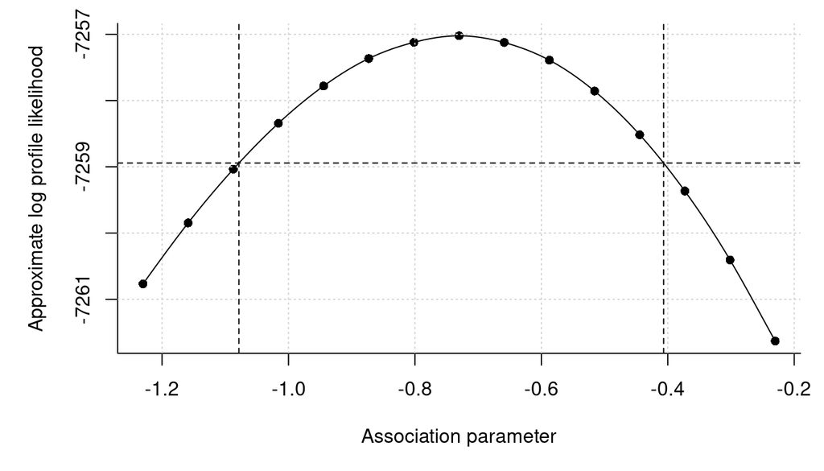

```r
# plot the approximate log profile likelihood and highlight the critical value
par(mar = c(5, 5, 1, 1))
plot(params, lbs_max, pch = 16, bty = "l", xlab = "Association parameter",
     ylab = "Approximate log profile likelihood")
grid()
smooth_est <- smooth.spline(params, lbs_max)
lines(predict(smooth_est, seq(min(params), max(params), length.out = 100)))

# mark the confidence interval
abline(h = -opt_out$value - qchisq(level, 1) / 2, lty = 2)
abline(v = conf_int, lty = 2)
```

The `joint_ms_profile` uses similar steps to the above to find approximate profile likelihood based confidence intervals. An example is shown below.

```r
# construct the approximate likelihood ratio based confidence interval
system.time(
  prof_conf <- joint_ms_profile(
    comp_obj, opt_out = opt_out, which_prof = which_fix, delta = .25,
    level = level,
    max_it = 1000L, pre_method = 3L, cg_tol = .2, c2 = .1))
```

```
#>
#> Finding the upper limit of the approximate profile likelihood curve
#> LogLike: -7258.1624 at        -0.480153
#> LogLike: -7261.6286 at        -0.230153
#> LogLike: -7259.3813 at        -0.371893. Lb, target, ub: -7259.3813, -7258.9426, -7258.1624
#> LogLike: -7258.8957 at        -0.410649. Lb, target, ub: -7259.3813, -7258.9426, -7258.8957
#>
#> Finding the lower limit of the approximate profile likelihood curve
#> LogLike: -7258.0417 at        -0.980153
#> LogLike: -7260.7667 at        -1.230153
#> LogLike: -7259.3134 at        -1.108822. Lb, target, ub: -7259.3134, -7258.9426, -7258.0417
#> LogLike: -7258.8517 at        -1.067539. Lb, target, ub: -7259.3134, -7258.9426, -7258.8517
#> LogLike: -7257.0219 at        -0.730153
#>    user  system elapsed
#>  89.602   0.016  22.409
```

```r
prof_conf$confs # the approximate confidence interval
```

```
#>  2.50 pct. 97.50 pct.
#>    -1.0760    -0.4067
```

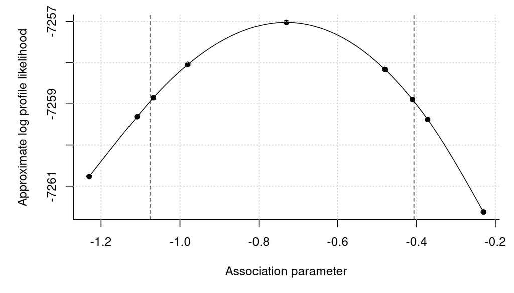

```r
# plot the approximate log profile likelihood and highlight the critical value
par(mar = c(5, 5, 1, 1))

with(prof_conf, {
  plot(xs, p_log_Lik, pch = 16, bty = "l",
     xlab = "Association parameter", ylab = "Approximate log profile likelihood")
  grid()
  smooth_est <- smooth.spline(xs, p_log_Lik)
  lines(predict(smooth_est, seq(min(xs), max(xs), length.out = 100)))

  abline(v = confs, lty = 2)
})
```

The Hessian can be used to possibly decrease the computation time by passing it to the `hess` argument as illustrated below. Starting values along the profile likelihood curve is then found using an approximate normal distribution.

```r
# construct the approximate likelihood ratio based confidence interval
system.time(
  prof_conf_fast <- joint_ms_profile(
    comp_obj, opt_out = opt_out, which_prof = which_fix,
    # we can use the standard error
    delta = 2.5 * sqrt(diag(solve(hess$hessian)))[which_fix],
    level = level,
    max_it = 1000L, pre_method = 3L, cg_tol = .2, c2 = .1,
    hess = hess))
```

```
#> Computing the vector to find the starting values along the profile likelihood curve
#>
#> Finding the upper limit of the approximate profile likelihood curve
#> LogLike: -7260.3169 at        -0.307229
#> LogLike: -7257.0219 at        -0.730153
#> LogLike: -7257.8966 at        -0.511013. Lb, target, ub: -7260.3169, -7258.9426, -7257.8966
#> LogLike: -7258.9272 at        -0.407852. Lb, target, ub: -7260.3169, -7258.9426, -7258.9272
#> LogLike: -7259.0783 at        -0.395511. Lb, target, ub: -7259.0783, -7258.9426, -7258.9272
#>
#> Finding the lower limit of the approximate profile likelihood curve
#> LogLike: -7259.8232 at        -1.153077
#> LogLike: -7257.0219 at        -0.730153
#> LogLike: -7258.1134 at        -0.987911. Lb, target, ub: -7259.8232, -7258.9426, -7258.1134
#> LogLike: -7258.9025 at        -1.072728. Lb, target, ub: -7259.8232, -7258.9426, -7258.9025
#> LogLike: -7259.0333 at        -1.085092. Lb, target, ub: -7259.0333, -7258.9426, -7258.9025
#> LogLike: -7257.0219 at        -0.730153
#>    user  system elapsed
#>  65.725   1.184  25.597
```

```r
# we got the same
prof_conf$confs
```

```
#>  2.50 pct. 97.50 pct.
#>    -1.0760    -0.4067
```

```r
prof_conf_fast$confs
```

```
#>  2.50 pct. 97.50 pct.
#>    -1.0766    -0.4066
```

### Two Markers and a Recurrent Event Without Frailty

In this section, we estimate a model like before but without the frailty.

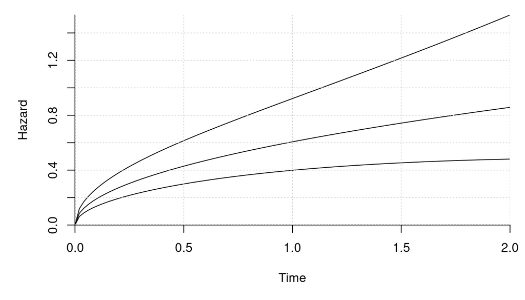

```r
# set the frailty variance to ~0
vcov_surv <- matrix(1e-6^2, 1)

# plot the hazard with pointwise quantiles
par(mar = c(5, 5, 1, 1))
plot_surv(
  time_fixef = b_term,
  time_rng = list(
    ns_term(knots = numeric(), Boundary.knots = c(0, 2), intercept = TRUE),
    poly_term(degree = 1, raw = TRUE, intercept = TRUE)),
  x_range = c(0, 2), vcov_vary = vcov_vary, frailty_var = vcov_surv,
  ps = c(.25, .5, .75), log_hazard_shift = fixef_surv[1],
  fixef_vary = fixef_vary_surv, associations = associations)
```

```r
# sample a moderately large data set
set.seed(2)
dat <- sim_dat(1000L)

# we show a few properties of the data below
NROW(dat$marker_data) # number of observed marker
```

```
#> [1] 4480
```

```r
NROW(dat$surv_data) # number of survival outcomes
```

```
#> [1] 2566
```

```r
sum(dat$surv_data$event) # number of observed events
```

[output not shown]

```r
# the data for one individual
subset(dat$marker_data, id == 1)
```

```
#>       Y1     Y2     X1_1   time id
#> 5     NA 4.3373 -0.23970 1.8877  1
#> 4     NA 4.8558  0.70795 1.8869  1
#> 3     NA 3.1915  0.13242 1.4047  1
#> 2  1.399 1.7030 -0.08025 1.1467  1
#> 1 -1.286 0.4379 -1.13038 0.3361  1
```

```r
subset(dat$surv_data, id == 1)
```

```
#>   lf_trunc     y event     Z_1 id
#> 2    1.206 1.330     1 -0.9706  1
#> 3    1.330 2.000     0 -0.9706  1
#> 1    0.000 1.206     1 -0.9706  1
```

```r
# distribution of observed events per individual
proportions(table(table(dat$surv_data$id) - 1L))
```

```
#>
#>     0     1     2     3     4     5     6     7     8     9
#> 0.317 0.279 0.184 0.102 0.057 0.029 0.010 0.007 0.004 0.011
```

```r
# estimate the model with this package. Get the object we need for the
# optimization
marker_1 <- marker_term(
    Y1 ~ X1_1, id = id, subset(dat$marker_data, !is.na(Y1)),
    time_fixef = ns_term(time, knots = c(.5, 1.5), Boundary.knots = c(0, 2)),
    time_rng = ns_term(time, knots = numeric(), Boundary.knots = c(0, 2),
                       intercept = TRUE))
marker_2 <- marker_term(
    Y2 ~ 1, id = id, subset(dat$marker_data, !is.na(Y2)),
    time_fixef = poly_term(time, degree = 2, raw = TRUE),
    time_rng = poly_term(time, degree = 1, raw = TRUE, intercept = TRUE))

surv_obj <- surv_term(
  Surv(lf_trunc, y, event) ~ Z_1, id = id, dat$surv_data,
  # we select a more flexible model for the baseline hazard
  time_fixef = poly_term(y, degree = 3L, raw = TRUE, use_log = TRUE))

comp_obj <- joint_ms_ptr(markers = list(marker_1, marker_2),
                         survival_terms = surv_obj, max_threads = 4L)
rm(marker_1, marker_2, surv_obj)

# get the starting values
system.time(start_val <- joint_ms_start_val(comp_obj))
```

```
#>    user  system elapsed
#>   2.596   0.000   0.750
```

```r
# lower bound at the starting values
print(-attr(start_val, "value"), digits = 8)
```

```
#> [1] -7423.5688
```

```r
# check that the gradient is correct
f <- function(x){
  start_val[seq_along(x)] <- x
  joint_ms_lb(comp_obj, start_val)
}

all.equal(numDeriv::grad(f, head(start_val, 28 + 2 * 14)),
          head(joint_ms_lb_gr(comp_obj, start_val), 28 + 2 * 14))
```

```
#> [1] "Mean relative difference: 1.514e-07"
```

```r
# find the maximum lower bound estimate
system.time(opt_out <- joint_ms_opt(comp_obj, par = start_val, max_it = 1000L,
                                    pre_method = 3L, cg_tol = .2, c2 = .1,
                                    rel_eps = 1e-10))
```

```
#>    user  system elapsed
#>  10.709   0.000   2.678
```

```r
# check the gradient norm. We may need to reduce the convergence tolerance if
# this is not small. In can also be a sign of convergence issues
sqrt(sum(joint_ms_lb_gr(comp_obj, opt_out$par)^2))
```

```
#> [1] 0.01839
```

```r
opt_out$info # convergence code (0 == 'OK')
```

```
#> [1] 0
```

```r
print(-opt_out$value, digits = 8) # maximum lower bound value
```

```
#> [1] -7093.4009
```

```r
opt_out$counts
```

```
#> function gradient     n_cg
#>      412      308      685
```

```r
# compare the estimates with the actual values. Start with the fixed effects
fmt_ests <- joint_ms_format(comp_obj, opt_out$par)

# the parameters for the first marker
fmt_ests$markers[[1]]
```

```
#> $fixef
#> [1] -0.5361  1.0058
#>
#> $fixef_vary
#> [1]  1.439 -1.134 -2.067
```

```r
fixef_marker[[1]] # true values
```

```
#> [1] -0.5  1.0
```

```r
fixef_vary_marker[[1]] # true values
```

```
#> [1]  1.4 -1.2 -2.1
```

```r
# the parameters for the second marker
fmt_ests$markers[[2]]
```

```
#> $fixef
#> [1] 0.2043
#>
#> $fixef_vary
#> [1] 0.6436 0.6173
```

```r
fixef_marker[[2]] # true values
```

```
#> [1] 0.25
```

```r
fixef_vary_marker[[2]] # true values
```

```
#> [1] 0.50 0.67
```

```r
# the fixed effects for the survival outcome and the association parameters
fmt_ests$survival[[1]]
```

```
#> $fixef
#> [1] -0.4367  0.2499
#>
#> $fixef_vary
#> [1]  0.426456 -0.006997  0.010090
#>
#> $associations
#> [1] -0.8852  0.7342
```

```r
fixef_surv
```

```
#> [1] -0.50  0.25
```

```r
fixef_vary_surv
```

```
#> [1] 0.5
```

```r
associations
```

```
#> [1] -0.8  0.7
```

```r
# the parameters for covariance matrix of the random effects
fmt_ests$vcov$vcov_vary
```

```
#>          [,1]     [,2]     [,3]     [,4]
#> [1,]  0.30519  0.01912 -0.06209  0.02126
#> [2,]  0.01912  0.08415 -0.03358 -0.02355
#> [3,] -0.06209 -0.03358  0.30457  0.08503
#> [4,]  0.02126 -0.02355  0.08503  0.14096
```

```r
vcov_vary # the true values
```

```
#>       [,1]  [,2]  [,3]  [,4]
#> [1,]  0.35  0.02 -0.05  0.01
#> [2,]  0.02  0.12 -0.06 -0.01
#> [3,] -0.05 -0.06  0.32  0.09
#> [4,]  0.01 -0.01  0.09  0.12
```

```r
# the parameters for the error term covariance matrix
fmt_ests$vcov$vcov_marker
```

```
#>         [,1]    [,2]
#> [1,] 0.36068 0.09824
#> [2,] 0.09824 0.15530
```

```r
vcov_marker
```

```
#>      [,1] [,2]
#> [1,] 0.36 0.10
#> [2,] 0.10 0.16
```

```r
# the parameters for the frailty covariance matrix
fmt_ests$vcov$vcov_surv # NULL as there is not any
```

#### Using the Estimated Variational Parameters

The `joint_ms_va_par` function can be used to extract the estimated variational parameters for each individual. These can be used to get marginal estimates as the variational approximation for each individual is an approximation of the conditional distribution of the random effects given the observed data.

```r
# get the variational parameters
va_par <- joint_ms_va_par(comp_obj, opt_out$par)

# it is a list with the estimated variational parameters for each individual
va_par[c("157", "345", "878")]
```

```
#> $`157`
#> $`157`$mean
#> [1] -0.47330 -0.02991  0.85787  0.37735
#>
#> $`157`$vcov
#>           [,1]       [,2]      [,3]       [,4]
#> [1,]  0.196318 -0.0094526 -0.011039  0.0255789
#> [2,] -0.009453  0.0673965  0.003971  0.0006195
#> [3,] -0.011039  0.0039709  0.098737 -0.0459746
#> [4,]  0.025579  0.0006195 -0.045975  0.0412363
#>
#>
#> $`345`
#> $`345`$mean
#> [1] -0.03225 -0.11438  0.92849  0.42211
#>
#> $`345`$vcov
#>           [,1]      [,2]      [,3]      [,4]
#> [1,]  0.184687  0.015121 -0.005131  0.032541
#> [2,]  0.015121  0.072400 -0.001714  0.001443
#> [3,] -0.005131 -0.001714  0.038312 -0.029648
#> [4,]  0.032541  0.001443 -0.029648  0.064868
#>
#>
#> $`878`
#> $`878`$mean
#> [1] 0.23917 0.03414 0.25500 0.14914
#>
#> $`878`$vcov
#>           [,1]       [,2]      [,3]       [,4]
#> [1,]  0.189760  2.005e-02 -0.004532  1.121e-02
#> [2,]  0.020050  7.357e-02 -0.004647 -5.375e-05
#> [3,] -0.004532 -4.647e-03  0.055990 -2.593e-02
#> [4,]  0.011207 -5.375e-05 -0.025934  4.042e-02
```

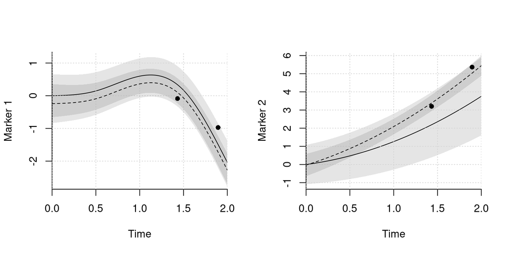

```r
# they can be used to approximate marginal measures such as the mean curve for
# the individual along with 95% pointwise confidence intervals as shown below
# for where the true curve is. You can skip the code below and go the plots after
plot_mean_curve <- function(who){
  # get the data for the individual
  m_dat <- subset(dat$marker_data, id == who)

  # plot the estimated mean population curve with pointwise confidence intervals
  par(mfcol = c(1, 2), bty = "l")
  fmt_ests <- joint_ms_format(comp_obj, opt_out$par)
  plot_marker(
    time_fixef = ns_term(
      knots = c(.5, 1.5), Boundary.knots = c(0, 2)),
    time_rng = ns_term(
      knots = numeric(), Boundary.knots = c(0, 2), intercept = TRUE),
    fixef_vary = fmt_ests$markers[[1]]$fixef_vary, x_range = c(0, 2),
    vcov_vary = fmt_ests$vcov$vcov_vary[1:2, 1:2], ylab = "Marker 1")

  # add the points for the individual
  y_hat <- m_dat$Y1 - cbind(1, m_dat$X1_1) %*% fmt_ests$markers[[1]]$fixef
  points(m_dat$time, y_hat, pch = 16)

  # plot the estimated mean curve with pointwise confidence intervals
  va_par_who <- va_par[[who]]
  xs <- seq(0, 2, length.out = 100)
  mea <- g_funcs[[1]](xs) %*% fmt_ests$markers[[1]]$fixef_vary +
    m_funcs[[1]](xs) %*% va_par_who$mean[1:2]
  lines(xs, mea, lty = 2)
  se <- apply(m_funcs[[1]](xs), 1, function(x)
    sqrt(x %*% va_par_who$vcov[1:2, 1:2] %*% x))
  polygon(c(xs, rev(xs)), c(mea + 1.96 * se, rev(mea - 1.95 * se)), border = NA,
          col = gray(0, .1))

  # plot the estimated mean population curve with pointwise confidence intervals
  plot_marker(
    time_fixef = poly_term(degree = 2, raw = TRUE),
    time_rng = poly_term(degree = 1, raw = TRUE, intercept = TRUE),
    fixef_vary = fmt_ests$markers[[2]]$fixef_vary, x_range = c(0, 2),
    vcov_vary = fmt_ests$vcov$vcov_vary[3:4, 3:4], ylab = "Marker 2")

  # add the points for the individual
  y_hat <- m_dat$Y2 - fmt_ests$markers[[2]]$fixef
  points(m_dat$time, y_hat, pch = 16)

  # plot the estimated mean curve with confidence intervals
  xs <- seq(0, 2, length.out = 100)
  mea <- g_funcs[[2]](xs) %*% fmt_ests$markers[[2]]$fixef_vary +
    m_funcs[[2]](xs) %*% va_par_who$mean[2:3]
  lines(xs, mea, lty = 2)
  se <- apply(m_funcs[[2]](xs), 1, function(x)
    sqrt(x %*% va_par_who$vcov[3:4, 3:4] %*% x))
  polygon(c(xs, rev(xs)), c(mea + 1.96 * se, rev(mea - 1.95 * se)), border = NA,
          col = gray(0, .1))
}

# plot the curves for three individuals
plot_mean_curve(157)
```

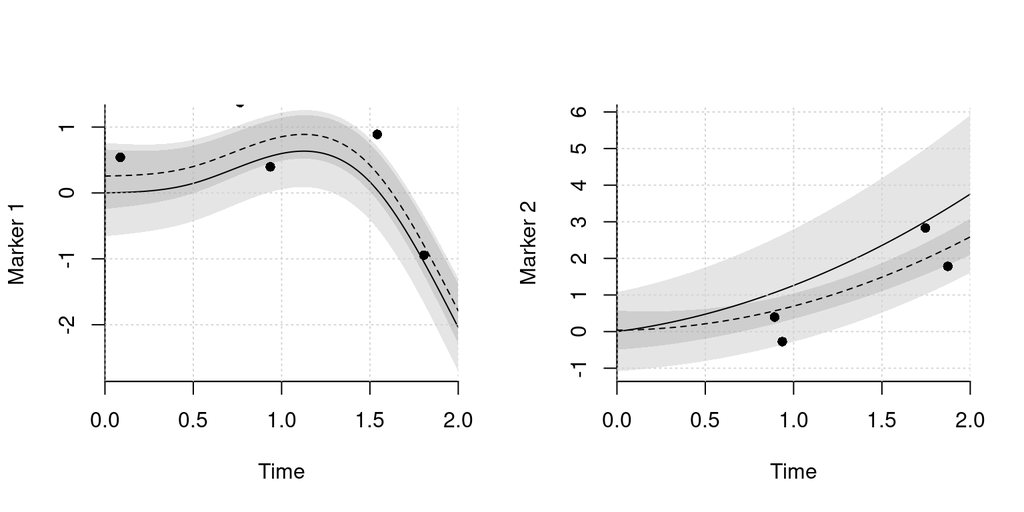

```r
plot_mean_curve(235)
```

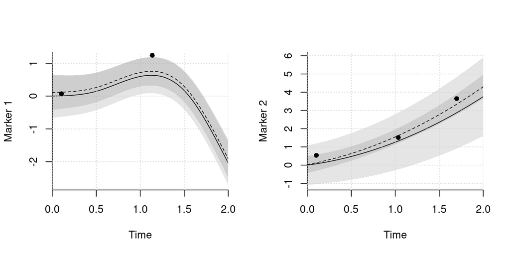

```r
plot_mean_curve(878)
```

### Two Markers, the Observation Time Process, and a Terminal Event

We simulate and fit a model in this section where we have two markers, a recurrent event which is the observation times, and a terminal event.

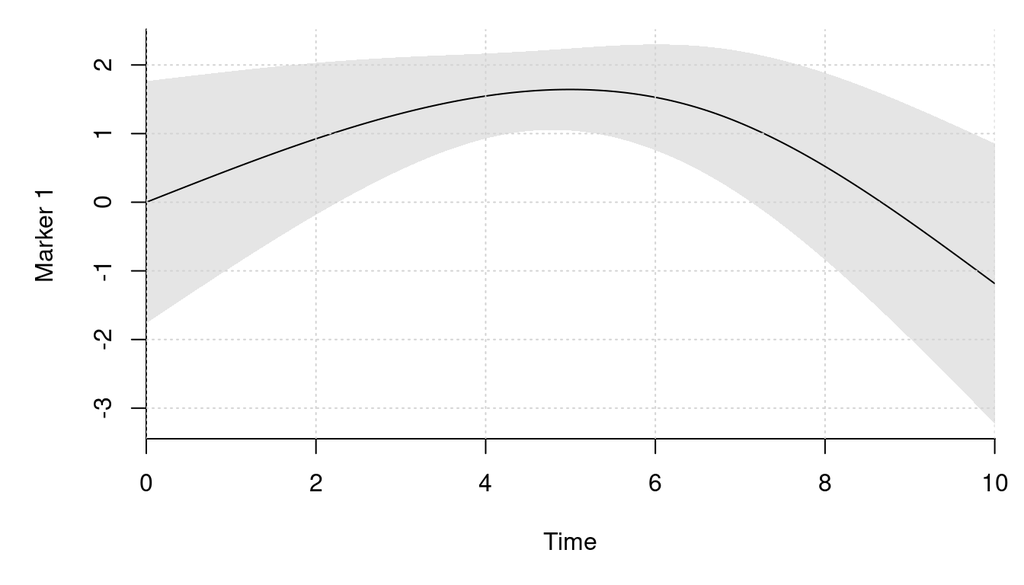

```r
# settings for the simulation
library(splines)
g_funcs <- list(
  function(x)
    ns(x, knots = c(3.33, 6.67), Boundary.knots = c(0, 10)),
  function(x)
    # a raw polynomial
    outer(x, 1:2, `^`))
m_funcs <- list(
  function(x)
    ns(x, knots = numeric(), Boundary.knots = c(0, 10), intercept = TRUE),
  function(x)
    # a raw polynomial
    outer(x, 0:1, `^`))

fixef_vary_marker <- list(c(1.4, 1.2, -2.1), c(.5, -.02)) # beta
fixef_marker <- list(c(-.5, 2), 1) # gamma

# Psi
vcov_vary <- structure(c(0.35, 0.08, -0.05, 0.01, 0.08, 1.92, -0.24, -0.04,
                   -0.05, -0.24, 0.32, 0.09, 0.01, -0.04, 0.09, 0.12),
                 .Dim = c(4L, 4L))
vcov_marker <- matrix(c(.6^2, .1, .1, .4^2), 2)

# plot the markers' mean curve
library(VAJointSurv)
par(mar = c(5, 5, 1, 1))
plot_marker(
  time_fixef = ns_term(
    knots = c(3.33, 6.67), Boundary.knots = c(0, 10), intercept = FALSE),
  time_rng = ns_term(
    knots = numeric(), Boundary.knots = c(0, 10), intercept = TRUE),
  fixef_vary = fixef_vary_marker[[1]], x_range = c(0, 10),
  vcov_vary = vcov_vary[1:2, 1:2], ylab = "Marker 1")
```

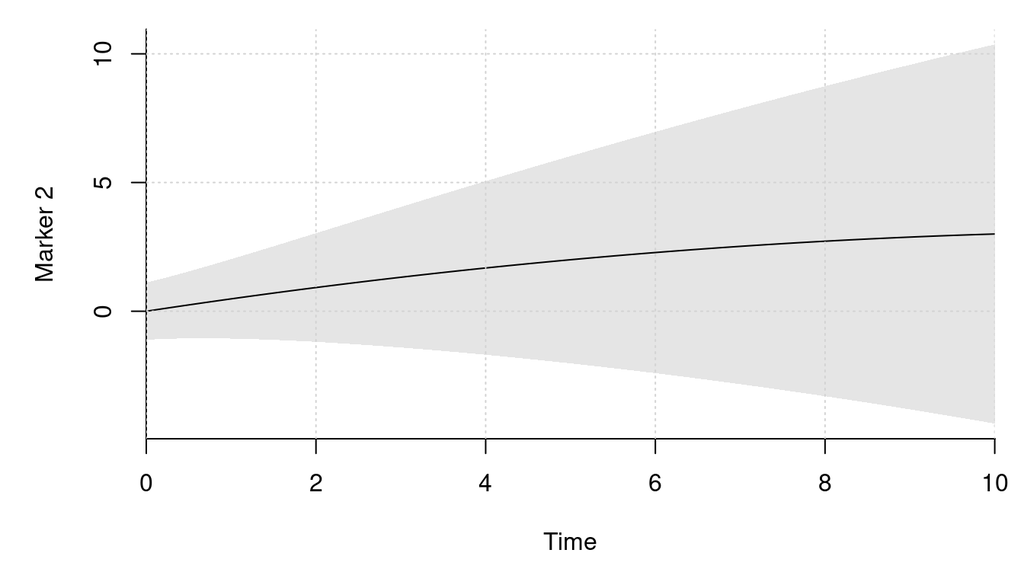

```r
plot_marker(
  time_fixef = poly_term(degree = 2, raw = TRUE),
  time_rng = poly_term(degree = 1, raw = TRUE, intercept = TRUE),
  fixef_vary = fixef_vary_marker[[2]], x_range = c(0, 10),
  vcov_vary = vcov_vary[3:4, 3:4], ylab = "Marker 2")
```

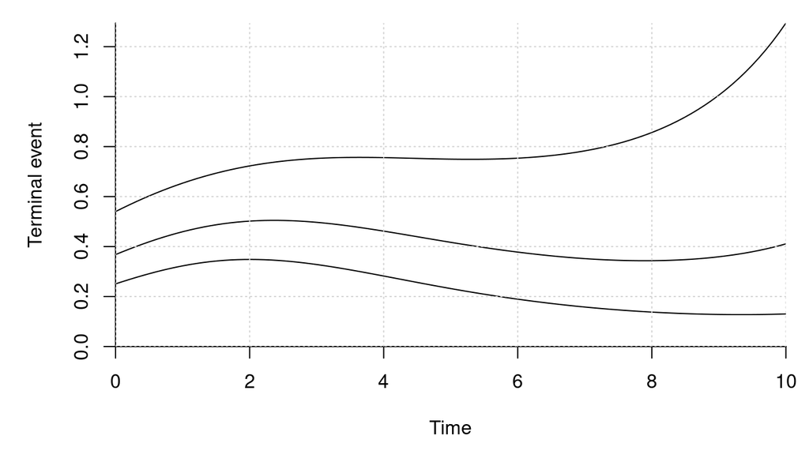

```r
# the survival parameters
vcov_surv <- matrix(c(.2^2, .15^2, .15^2, .25^2), 2) # Xi

fixef_surv <- list(c(-1, .25), .2)
associations <- list(c(.6, -.4), c(-.7, .2))
fixef_vary_surv <- list(c(.5, .1, -.2, .11),
                          c(-1, -.25))

b_funcs <- list(
  function(x) bs(x, knots = 5, Boundary.knots = c(0, 10)),
  function(x) ns(x, knots = 5, Boundary.knots = c(0, 10)))

# plot the log hazard with the 25%, 50% and 75% quantiles
library(SimSurvNMarker)

plot_surv(
  time_fixef = bs_term(knots = 5, Boundary.knots = c(0, 10)),
  time_rng = list(
    ns_term(knots = numeric(), Boundary.knots = c(0, 10), intercept = TRUE),
    poly_term(degree = 1, raw = TRUE, intercept = TRUE)),
  x_range = c(0, 10), fixef_vary = fixef_vary_surv[[1]],
  vcov_vary = vcov_vary, frailty_var = vcov_surv[1, 1], ps = c(.25, .5, .75),
  associations = associations[[1]], log_hazard_shift = fixef_surv[[1]][1],
  ylab = "Terminal event")
```

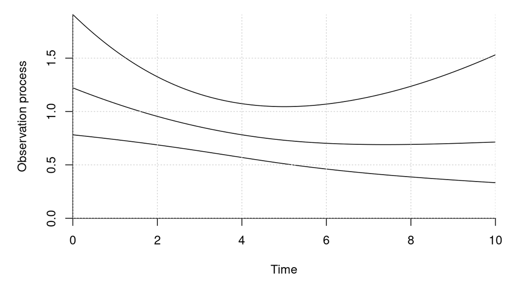

```r
plot_surv(
  time_fixef = ns_term(knots = 5, Boundary.knots = c(0, 10)),
  time_rng = list(
    ns_term(knots = numeric(), Boundary.knots = c(0, 10), intercept = TRUE),
    poly_term(degree = 1, raw = TRUE, intercept = TRUE)),
  x_range = c(0, 10), fixef_vary = fixef_vary_surv[[2]],
  vcov_vary = vcov_vary, frailty_var = vcov_surv[2, 2], ps = c(.25, .5, .75),
  associations = associations[[2]], log_hazard_shift = fixef_surv[[2]][1],
  ylab = "Observation process")
```

```r
library(mvtnorm)
# simulates from the model by sampling a given number of individuals
sim_dat <- function(n_ids){
  # simulate the outcomes
  gl_dat <- get_gl_rule(100L)
  dat <- lapply(1:n_ids, function(id){
    # sample the terminal event time and the censoring time
    cens <- min(rexp(1, rate = 1/10), 10)
    U <- drop(rmvnorm(1, sigma = vcov_vary))

    frailties <- drop(rmvnorm(1, sigma = vcov_surv))
    Z1 <- c(1, runif(1, -1, 1))
    log_haz_offset <- sum(Z1 * fixef_surv[[1]]) + frailties[1]

    # assign the conditional survival function
    expansion <- function(x, b_func)
      cbind(b_func(x), m_funcs[[1]](x) %*% U[1:2],
            m_funcs[[2]](x) %*% U[3:4])
    surv_func <- function(ti, fixef_vary_surv, associations, b_func){
      formals(expansion)$b_func <- b_func
      eval_surv_base_fun(
        ti = ti, omega = c(fixef_vary_surv, associations), b_func = expansion,
        gl_dat = gl_dat, delta = log_haz_offset)
    }

    # sample the survival time
    rng <- runif(1)
    root_func <- function(x, rng)
      rng - surv_func(x, fixef_vary_surv = fixef_vary_surv[[1]],
                      associations = associations[[1]], b_func = b_funcs[[1]])

    if(root_func(cens, rng) < 0){
      # the observation is censored
      y_terminal <- cens
      event <- 0
    } else {
      # find the event time
      root <- uniroot(root_func, c(0, cens), tol = 1e-6, rng = rng)
      y_terminal <- root$root
      event <- 1

    }

    terminal_outcome <- cbind(y = y_terminal, event = event, Z1 = Z1[2],
                              id = id)

    # clean up
    rm(list = setdiff(ls(), c("y_terminal", "terminal_outcome", "expansion",
                              "surv_func", "frailties", "U", "id")))

    # simulate the observation times
    Z2 <- 1
    log_haz_offset <- sum(Z2 * fixef_surv[[2]]) + frailties[2]

    root_func <- function(x, left_trunc_surv, rng)
      rng - surv_func(x, fixef_vary_surv = fixef_vary_surv[[2]],
                      associations = associations[[2]], b_func = b_funcs[[2]]) /
      left_trunc_surv

    max_sample <- 1000L
    left_trunc_surv <- 1
    Z2 <- matrix(rep(Z2, each = max_sample), max_sample)
    event <- y <- lf_trunc <- rep(NA_real_, max_sample)
    lf_trunc_i <- 0
    for(i in 1:max_sample){
      # sample a random uniform variable and invert the survival function
      rng_i <- runif(1)
      lf_trunc[i] <- lf_trunc_i

      if(root_func(y_terminal, left_trunc_surv, rng_i) < 0){
        # the observation is right-censored and we can exit
        y[i] <- y_terminal
        event[i] <- 0
        break
      }

      # we need to invert the survival function to find the observation time
      root <- uniroot(root_func, c(lf_trunc_i, y_terminal), tol = 1e-6,
                      left_trunc_surv = left_trunc_surv, rng = rng_i)
      lf_trunc_i <- y[i] <- root$root
      event[i] <- 1
      left_trunc_surv <- surv_func(
        y[i], fixef_vary_surv = fixef_vary_surv[[2]], associations = associations[[2]],
        b_func = b_funcs[[2]])
    }

    colnames(Z2) <- paste0("Z", 1:NCOL(Z2) - 1L)
    obs_process <- cbind(lf_trunc = lf_trunc[1:i], y = y[1:i],
                         event = event[1:i], Z2[1:i, -1, drop = FALSE],
                         id = id)

    # clean up
    rm(list = setdiff(ls(), c("terminal_outcome", "U", "id",
                              "obs_process")))

    # sample the fixed effect covariates
    obs_time <- c(0, obs_process[obs_process[, "event"] == 1, "y"])
    n_obs <- length(obs_time)
    X1 <- cbind(1, rnorm(n_obs))
    X2 <- matrix(1, n_obs)
    colnames(X1) <- paste0("X1_", 1:NCOL(X1) - 1L)
    colnames(X2) <- paste0("X2_", 1:NCOL(X2) - 1L)
    X <- list(X1, X2)

    # sample the outcomes
    eta <- sapply(1:2, function(i)
      X[[i]] %*% fixef_marker[[i]] +
        drop(g_funcs[[i]](obs_time)) %*% fixef_vary_marker[[i]] +
        drop(m_funcs[[i]](obs_time)) %*% U[1:2 + (i == 2) * 2])

    ys <- eta + rmvnorm(n_obs, sigma = vcov_marker)
    colnames(ys) <- paste0("Y", 1:2)

    # mask some observations
    do_mask <- sample.int(3L, n_obs, replace = TRUE)
    ys[do_mask == 2, 1] <- NA
    ys[do_mask == 3, 2] <- NA

    X <- do.call(cbind, lapply(X, function(x) x[, -1, drop = FALSE]))
    marker_data <- cbind(ys, X, time = obs_time, id = id)

    return(list(marker_data = marker_data, obs_process = obs_process,
                terminal_outcome = terminal_outcome))
  })

  # combine the data and return
  marker_data <- as.data.frame(do.call(
    rbind, lapply(dat, `[[`, "marker_data")))
  marker_data$id <- as.integer(marker_data$id)
  # the order does not matter
  marker_data <- marker_data[sample.int(NROW(marker_data)), ]

  obs_process <- as.data.frame(do.call(
    rbind, lapply(dat, `[[`, "obs_process")))
  obs_process$id <- as.integer(obs_process$id)
  # the order does not matter
  obs_process <- obs_process[sample.int(NROW(obs_process)), ]

  terminal_outcome <- as.data.frame(do.call(
    rbind, lapply(dat, `[[`, "terminal_outcome")))
  terminal_outcome$id <- as.integer(terminal_outcome$id)
  # the order does not matter
  terminal_outcome <- terminal_outcome[sample.int(NROW(terminal_outcome)), ]

  list(marker_data = marker_data, obs_process = obs_process,
       terminal_outcome = terminal_outcome)
}

# sample a moderately large data set
set.seed(2)
dat <- sim_dat(1000L)

# we show a few properties of the data below
mean(dat$terminal_outcome$event) # mean event rate
```

```
#> [1] 0.782
```

```r
sum(dat$obs_process$event) # number of observed markers less the individuals
```

```
#> [1] 2421
```

```r
NROW(dat$marker_data) # number of observed markers less the individuals
```

```
#> [1] 3421
```

```r
# distribution of observed marker per individual
proportions(table(table(dat$obs_process$id)))
```

```
#>
#>     1     2     3     4     5     6     7     8     9    10    11    12    13
#> 0.353 0.194 0.135 0.076 0.069 0.045 0.030 0.024 0.023 0.010 0.005 0.006 0.008
#>    14    15    16    17    18    19    20    21    22    23    24    25    26
#> 0.003 0.001 0.004 0.001 0.003 0.001 0.001 0.001 0.003 0.001 0.001 0.001 0.001
```

```r
# show data for one individual
subset(dat$marker_data, id == 1)
```

```
#>          Y1    Y2     X1_1   time id
#> X.3      NA 4.041 -0.02815 2.4032  1
#> X.2      NA 2.164 -1.03429 0.2988  1
#> X.1 -0.3812 2.646 -0.28571 0.2603  1
#> X   -2.6308 1.584 -1.43968 0.0000  1
```

```r
subset(dat$obs_process, id == 1)
```

```
#>   lf_trunc      y event id
#> 2   0.2603 0.2988     1  1
#> 1   0.0000 0.2603     1  1
#> 4   2.4032 2.8900     0  1
#> 3   0.2988 2.4032     1  1
```

```r
subset(dat$terminal_outcome, id == 1)
```

```
#>      y event      Z1 id
#> 1 2.89     1 -0.6384  1
```

```r
# estimate the model with this package. Get the object we need for the
# optimization
marker_1 <- marker_term(
  Y1 ~ X1_1, id = id, subset(dat$marker_data, !is.na(Y1)),
  time_fixef = ns_term(time, knots = c(3.33, 6.67), Boundary.knots = c(0, 10)),
  time_rng = ns_term(time, knots = numeric(), Boundary.knots = c(0, 10),
                     intercept = TRUE))
marker_2 <- marker_term(
  Y2 ~ 1, id = id, subset(dat$marker_data, !is.na(Y2)),
  time_fixef = poly_term(time, degree = 2, raw = TRUE),
  time_rng = poly_term(time, degree = 1, raw = TRUE, intercept = TRUE))

library(survival)
surv_terminal <- surv_term(
  Surv(y, event) ~ Z1, id = id, dat$terminal_outcome,
  time_fixef = bs_term(y, knots = 5, Boundary.knots = c(0, 10)),
  with_frailty = TRUE)
surv_obs <- surv_term(
  Surv(lf_trunc, y, event) ~ 1, id = id, dat$obs_process,
  time_fixef = ns_term(y, knots = 5, Boundary.knots = c(0, 10)),
  with_frailty = TRUE)

comp_obj <- joint_ms_ptr(markers = list(marker_1, marker_2),
                         survival_terms = list(surv_terminal, surv_obs),
                         max_threads = 4L)
rm(marker_1, marker_2, surv_terminal, surv_obs)

# get the starting values
system.time(start_val <- joint_ms_start_val(comp_obj, gr_tol = .1))
```

```
#>    user  system elapsed
#>  31.820   0.027   8.329
```

```r
# lower bound at the starting values
print(-attr(start_val, "value"), digits = 8)
```

```
#> [1] -7885.9054
```

```r
# check that the gradient is correct
f <- function(x){
  start_val[seq_along(x)] <- x
  joint_ms_lb(comp_obj, start_val)
}

all.equal(numDeriv::grad(f, head(start_val, 37 + 2 * 27)),
          head(joint_ms_lb_gr(comp_obj, start_val), 37 + 2 * 27),
          tolerance = 1e-6)
```

```
#> [1] TRUE
```

```r
# find the maximum lower bound estimate
system.time(opt_out <- joint_ms_opt(comp_obj, par = start_val, max_it = 2000L,
                                    pre_method = 3L, cg_tol = .2, c2 = .1,
                                    gr_tol = .1))
```

```
#>    user  system elapsed
#> 241.003   0.112  60.287
```

```r
# we set gr_tol in the call so this is the convergence criterion for the
# gradient
sqrt(sum(joint_ms_lb_gr(comp_obj, opt_out$par)^2))
```

```
#> [1] 0.09475
```

```r
opt_out$info # convergence code (0 == 'OK')
```

```
#> [1] 0
```

```r
print(-opt_out$value, digits = 8) # maximum lower bound value
```

```
#> [1] -7600.1724
```

```r
opt_out$counts
```

```
#> function gradient     n_cg
#>     3748     2665    19654
```

```r
# compare the estimates with the actual values. Start with the fixed effects
fmt_ests <- joint_ms_format(comp_obj, opt_out$par)

# the parameters for the first marker
fmt_ests$markers[[1]]
```

```
#> $fixef
#>
#> -0.5136  1.9734
#>
#> $fixef_vary
#>
#>  1.400  1.561 -1.606
```

```r
fixef_marker[[1]] # true values
```

```
#> [1] -0.5  2.0
```

```r
fixef_vary_marker[[1]] # true values
```

```
#> [1]  1.4  1.2 -2.1
```

```r
# the parameters for the second marker
fmt_ests$markers[[2]]
```

```
#> $fixef
#>
#> 1.036
#>
#> $fixef_vary
#>
#>  0.48410 -0.02007
```

```r
fixef_marker[[2]] # true values
```

```
#> [1] 1
```

```r
fixef_vary_marker[[2]] # true values
```

```
#> [1]  0.50 -0.02
```

```r
# the fixed effects for the survival outcome and the association parameters
# for the terminal event
fmt_ests$survival[[1]]
```

```
#> $fixef
#>
#> -0.8571  0.2568
#>
#> $fixef_vary
#>
#> -0.07556  1.17483 -1.33168  0.31447
#>
#> $associations
#>
#>  0.5676 -0.3621
```

```r
fixef_surv[[1]]
```

```
#> [1] -1.00  0.25
```

```r
fixef_vary_surv[[1]]
```

```
#> [1]  0.50  0.10 -0.20  0.11
```

```r
associations[[1]]
```

```
#> [1]  0.6 -0.4
```

```r
# same for the observation process
fmt_ests$survival[[2]]
```

```
#> $fixef
#>
#> 0.2476
#>
#> $fixef_vary
#>
#> -1.3520 -0.3493
#>
#> $associations
#>
#> -0.7369  0.2078
```

```r
fixef_surv[[2]]
```

```
#> [1] 0.2
```

```r
fixef_vary_surv[[2]]
```

```
#> [1] -1.00 -0.25
```

```r
associations[[2]]
```

```
#> [1] -0.7  0.2
```

```r
# the parameters for covariance matrix of the random effects
fmt_ests$vcov$vcov_vary
```

```
#>           [,1]      [,2]     [,3]     [,4]
#> [1,]  0.294322 -0.145392  0.05288 0.001029
#> [2,] -0.145392  1.481999 -0.12440 0.007732
#> [3,]  0.052880 -0.124399  0.27871 0.091861
#> [4,]  0.001029  0.007732  0.09186 0.116766
```

```r
vcov_vary # the true values
```

```
#>       [,1]  [,2]  [,3]  [,4]
#> [1,]  0.35  0.08 -0.05  0.01
#> [2,]  0.08  1.92 -0.24 -0.04
#> [3,] -0.05 -0.24  0.32  0.09
#> [4,]  0.01 -0.04  0.09  0.12
```

```r
# the parameters for the error term covariance matrix
fmt_ests$vcov$vcov_marker
```

```
#>        [,1]   [,2]
#> [1,] 0.3890 0.1104
#> [2,] 0.1104 0.1688
```

```r
vcov_marker
```

```
#>      [,1] [,2]
#> [1,] 0.36 0.10
#> [2,] 0.10 0.16
```

```r
# the parameters for the frailty covariance matrix
fmt_ests$vcov$vcov_surv
```

```
#>          [,1]     [,2]
#> [1,]  0.00693 -0.01237
#> [2,] -0.01237  0.02767
```

```r
vcov_surv
```

```
#>        [,1]   [,2]
#> [1,] 0.0400 0.0225
#> [2,] 0.0225 0.0625
```

#### Caching Expansions

Some basis expansions like `bs_term` and `ns_term` take relatively long time to evaluate in the approximation of the approximate expected cumulative hazard. Thus, it may be advantageous to save the expansions if the same quadrature rule is used. This is done by setting the `cache_expansions` argument to true. The pros of doing this is that the expensive basis expansions are only evaluated once which may decrees the computation time. The cons are

- We no longer use the CPU cache efficiently with present hardware. Thus, you may not see great advantages of using many threads and the performance  
  may even be worse. This is more likely to be an issue with larger data set.
- It requires a lot more memory which may be an issue larger problems.

We illustrate this by showing the computation time where we change the number of threads we use.

```r
# with caching
w_caching <- bench::mark(
  `w/ caching 1 thread` =
    joint_ms_lb(comp_obj, opt_out$par, n_threads = 1, cache_expansions = TRUE),
  `w/ caching 2 thread` =
    joint_ms_lb(comp_obj, opt_out$par, n_threads = 2, cache_expansions = TRUE),
  `w/ caching 3 thread` =
    joint_ms_lb(comp_obj, opt_out$par, n_threads = 3, cache_expansions = TRUE),
  `w/ caching 4 thread` =
    joint_ms_lb(comp_obj, opt_out$par, n_threads = 4, cache_expansions = TRUE))
w_caching[, c("expression", "median")]
```

```
#> # A tibble: 4 × 2
#>   expression            median
#>   <bch:expr>          <bch:tm>
#> 1 w/ caching 1 thread   7.29ms
#> 2 w/ caching 2 thread   3.93ms
#> 3 w/ caching 3 thread   2.66ms
#> 4 w/ caching 4 thread   2.17ms
```

```r
# difference between one and four threads
with(w_caching, median[4] / median[1])
```

```
#> [1] 297ms
```

```r
# w/o caching
wo_caching <- bench::mark(
  `w/o caching 1 thread` =
    joint_ms_lb(comp_obj, opt_out$par, n_threads = 1, cache_expansions = FALSE),
  `w/o caching 2 thread` =
    joint_ms_lb(comp_obj, opt_out$par, n_threads = 2, cache_expansions = FALSE),
  `w/o caching 3 thread` =
    joint_ms_lb(comp_obj, opt_out$par, n_threads = 3, cache_expansions = FALSE),
  `w/o caching 4 thread` =
    joint_ms_lb(comp_obj, opt_out$par, n_threads = 4, cache_expansions = FALSE))
wo_caching[, c("expression", "median")]
```

```
#> # A tibble: 4 × 2
#>   expression             median
#>   <bch:expr>           <bch:tm>
#> 1 w/o caching 1 thread   53.6ms
#> 2 w/o caching 2 thread   30.8ms
#> 3 w/o caching 3 thread   21.9ms
#> 4 w/o caching 4 thread   17.7ms
```

```r
# difference between one and four threads
with(wo_caching, median[4] / median[1])
```

```
#> [1] 331ms
```

### Two Markers, the Observation Time Process, and a Terminal Event with Delayed Entry

We alter the previous example in this section by adding delayed entries. In this case, the likelihood has to be altered to account for the delayed entry as described by Crowther et al. (2016) and Berg and Drepper (2016).

To show the likelihood we use, assume that there is only one type of survival outcome, $H = 1$. The log marginal likelihood of individual $i$ where we do not properly account for the delayed entry is

$$\log E\left( f_i(\vec y_i\mid \vec U_i)h_{i1}(t_{i1}\mid \vec U_i)^{d_{i1}} \frac{S_{i1}(t_{i1}\mid \vec U_i)}{S_{i1}(v_{i1}\mid \vec U_i)}\right)$$

where $\vec y_i$ is observed markers of individual $i$, $f_i$ is the conditional density for the markers of individual $i$ given the random effects $\vec U_i$, $t_{i1}$ is the observed time, $d_{i1}$ is an event indicator, $h_{i1}$ is the conditional hazard, $S_{i1}$ is the conditional survival function, and $v_{i1}\in [0,\infty)$ is the left-truncation time. We approximate the log marginal likelihood term with a lower bound given by

$$\log E\left( f_i(\vec y_i\mid \vec U_i)h_{i1}(t_{i1}\mid \vec U_i)^{d_{i1}} \frac{S_{i1}(t_{i1}\mid \vec U_i)}{S_{i1}(v_{i1}\mid \vec U_i)}\right) \geq E_{Q_{i1}}\left(\log\left( f_i(\vec y_i\mid \vec U_i)h_{i1}(t_{i1}\mid \vec U_i)^{d_{i1}} \frac{S_{i1}(t_{i1}\mid \vec U_i)v(\vec U_i)} {S_{i1}(v_{i1}\mid \vec U_i)q_{\vec\theta_{i1}}(\vec U_i)} \right)\right)$$

where the expectation on the right-hand side is using the density $q_{\vec\theta_{i1}}$ and $v$ is the unconditional density of the random effects. Since this is a lower bound, we can jointly optimize the lower bound over the $\vec\theta_{i1}$s and the model parameters.

The correct likelihood with delayed entry is

$$\log E\left( f_i(\vec y_i\mid \vec U_i)h_{i1}(t_{i1}\mid \vec U_i)^{d_{i1}} S_{i1}(t_{i1}\mid \vec U_i)\right) - \log E\left(S_{i1}(v_{i1}\mid \vec U_i)\right).$$

Of course, we can replace this with an approximation in the form of

$$E_{Q_{i1}}\left(\log\left( f_i(\vec y_i\mid \vec U_i)h_{i1}(t_{i1}\mid \vec U_i)^{d_{i1}} S_{i1}(t_{i1}\mid \vec U_i)\frac{v(\vec U_i)}{q_{\theta_{i1}}(\vec U_i)} \right)\right) - E_{Q_{i2}}\left(\log\left(S_{i1}(v_{i1}\mid \vec U_i) \frac{v(\vec U_i)}{q_{\theta_{i2}}(\vec U_i)}\right)\right).$$

This has some implications:

1. We still need to maximize over the $\vec\theta_{i1}$s and the model parameters. However, we have to minimize over the $\vec\theta_{i2}$s as they provide an upper bound on the log marginal likelihood. Thus, we have a maxmin problem rather than a pure maximization problem.
2. The approximation is no longer guaranteed to be a lower bound on the log marginal likelihood because we are adding a lower bound on one term with an upper bound on the other term.
3. The approximation of $\log E\left(S_{i1}(v_{i1}\mid \vec U_i)\right)$ may be poor as we do not have the multivariate normal density from the markers.

Currently, we compute the terms in the marginal likelihood due to delayed entry with adaptive Gauss-Hermite quadrature. This can be quite slow if there are many random effects that needs to marginalized out. However, it seems that quite few quadrature nodes can be used to approximate the terms from delayed entry when the marginal survival probabilities are close to one (and the variance of the random effects are not extremely large). However, more quadrature nodes seems to be needed for the gradient of marginal likelihood terms due to delayed entry. Thus, you may experience odd behavior (very small improvements in the likelihood approximation at each step) of the optimizer if more quadrature nodes are needed.

We do believe that the maxmin problem mentioned in 1. can be solved efficiently but our preliminary “brute force” attempts were not fast.

Delayed entry is handled by the `delayed` argument of `surv_term` as illustrated in the example below.

```r
library(mvtnorm)
# simulates from the model by sampling a given number of individuals
sim_dat <- function(n_ids){
  # simulate the outcomes
  gl_dat <- get_gl_rule(100L)
  dat <- lapply(1:n_ids, function(id){
    # sample the delayed entry time
    delayed_entry <- pmax(runif(1, -.2, 1), 0)

    # sample the censoring time
    cens <- -Inf
    while(cens < delayed_entry)
      cens <- min(rexp(1, rate = 1/10), 10)

    # sample the terminal event time and the random effects
    Z1 <- c(1, runif(1, -1, 1))

    y_terminal <- -Inf
    while(y_terminal < delayed_entry){
      U <- drop(rmvnorm(1, sigma = vcov_vary))
      frailties <- drop(rmvnorm(1, sigma = vcov_surv))
      log_haz_offset <- sum(Z1 * fixef_surv[[1]]) + frailties[1]

      # assign the conditional survival function
      expansion <- function(x, b_func)
        cbind(b_func(x), m_funcs[[1]](x) %*% U[1:2],
              m_funcs[[2]](x) %*% U[3:4])
      surv_func <- function(ti, fixef_vary_surv, associations, b_func){
        formals(expansion)$b_func <- b_func
        eval_surv_base_fun(
          ti = ti, omega = c(fixef_vary_surv, associations), b_func = expansion,
          gl_dat = gl_dat, delta = log_haz_offset)
      }

      # sample the survival time
      rng <- runif(1)
      root_func <- function(x, rng)
        rng - surv_func(x, fixef_vary_surv = fixef_vary_surv[[1]],
                        associations = associations[[1]], b_func = b_funcs[[1]])

      if(root_func(cens, rng) < 0){
        # the observation is censored
        y_terminal <- cens
        event <- 0
      } else {
        # find the event time
        root <- uniroot(root_func, c(0, cens), tol = 1e-6, rng = rng)
        y_terminal <- root$root
        event <- 1

      }
    }

    terminal_outcome <- cbind(y = y_terminal, event = event, Z1 = Z1[2],
                              id = id, delayed_entry = delayed_entry)

    # clean up
    rm(list = setdiff(ls(), c(
      "y_terminal", "terminal_outcome", "expansion", "surv_func", "frailties",
      "U", "id", "delayed_entry")))

    # simulate the observation times
    Z2 <- 1
    log_haz_offset <- sum(Z2 * fixef_surv[[2]]) + frailties[2]

    root_func <- function(x, left_trunc_surv, rng)
      rng - surv_func(x, fixef_vary_surv = fixef_vary_surv[[2]],
                      associations = associations[[2]], b_func = b_funcs[[2]]) /
      left_trunc_surv

    max_sample <- 1000L
    left_trunc_surv <- 1
    Z2 <- matrix(rep(Z2, each = max_sample), max_sample)
    event <- y <- lf_trunc <- rep(NA_real_, max_sample)
    lf_trunc_i <- 0
    for(i in 1:max_sample){
      # sample a random uniform variable and invert the survival function
      rng_i <- runif(1)
      lf_trunc[i] <- lf_trunc_i

      if(root_func(y_terminal, left_trunc_surv, rng_i) < 0){
        # the observation is right-censored and we can exit
        y[i] <- y_terminal
        event[i] <- 0
        break
      }

      # we need to invert the survival function to find the observation time
      root <- uniroot(root_func, c(lf_trunc_i, y_terminal), tol = 1e-6,
                      left_trunc_surv = left_trunc_surv, rng = rng_i)
      lf_trunc_i <- y[i] <- root$root
      event[i] <- 1
      left_trunc_surv <- surv_func(
        y[i], fixef_vary_surv = fixef_vary_surv[[2]], associations = associations[[2]],
        b_func = b_funcs[[2]])
    }

    colnames(Z2) <- paste0("Z", 1:NCOL(Z2) - 1L)
    obs_process <- cbind(lf_trunc = lf_trunc[1:i], y = y[1:i],
                         event = event[1:i], Z2[1:i, -1, drop = FALSE],
                         id = id)

    # account for the delayed entry
    obs_process[, "lf_trunc"] <- pmax(delayed_entry, obs_process[, "lf_trunc"])
    obs_process <- obs_process[
      obs_process[, "y"] > delayed_entry, , drop = FALSE]

    # clean up
    rm(list = setdiff(ls(), c("terminal_outcome", "U", "id",
                              "obs_process", "delayed_entry")))

    # sample the fixed effect covariates
    obs_time <- c(delayed_entry, obs_process[obs_process[, "event"] == 1, "y"])

    n_obs <- length(obs_time)
    X1 <- cbind(1, rnorm(n_obs))
    X2 <- matrix(1, n_obs)
    colnames(X1) <- paste0("X1_", 1:NCOL(X1) - 1L)
    colnames(X2) <- paste0("X2_", 1:NCOL(X2) - 1L)
    X <- list(X1, X2)

    # sample the outcomes
    eta <- sapply(1:2, function(i)
      X[[i]] %*% fixef_marker[[i]] +
        drop(g_funcs[[i]](obs_time)) %*% fixef_vary_marker[[i]] +
        drop(m_funcs[[i]](obs_time)) %*% U[1:2 + (i == 2) * 2])

    ys <- eta + rmvnorm(n_obs, sigma = vcov_marker)
    colnames(ys) <- paste0("Y", 1:2)

    # mask some observations
    do_mask <- sample.int(3L, n_obs, replace = TRUE)
    ys[do_mask == 2, 1] <- NA
    ys[do_mask == 3, 2] <- NA

    X <- do.call(cbind, lapply(X, function(x) x[, -1, drop = FALSE]))
    marker_data <- cbind(ys, X, time = obs_time, id = id)

    return(list(marker_data = marker_data, obs_process = obs_process,
                terminal_outcome = terminal_outcome))
  })

  # combine the data and return
  marker_data <- as.data.frame(do.call(
    rbind, lapply(dat, `[[`, "marker_data")))
  marker_data$id <- as.integer(marker_data$id)
  # the order does not matter
  marker_data <- marker_data[sample.int(NROW(marker_data)), ]

  obs_process <- as.data.frame(do.call(
    rbind, lapply(dat, `[[`, "obs_process")))
  obs_process$id <- as.integer(obs_process$id)
  # the order does not matter
  obs_process <- obs_process[sample.int(NROW(obs_process)), ]

  terminal_outcome <- as.data.frame(do.call(
    rbind, lapply(dat, `[[`, "terminal_outcome")))
  terminal_outcome$id <- as.integer(terminal_outcome$id)
  # the order does not matter
  terminal_outcome <- terminal_outcome[sample.int(NROW(terminal_outcome)), ]

  list(marker_data = marker_data, obs_process = obs_process,
       terminal_outcome = terminal_outcome)
}

# sample a moderate sized data set
set.seed(2)
dat <- sim_dat(1000L)

# we show a few properties of the data below
mean(dat$terminal_outcome$event) # mean event rate
```

```
#> [1] 0.776
```

```r
sum(dat$obs_process$event) # number of observed markers less the individuals
```

```
#> [1] 2620
```

```r
NROW(dat$marker_data) # number of observed markers less the individuals
```

```
#> [1] 3620
```

```r
# fraction of individuals with a delayed entry time
mean(dat$terminal_outcome$delayed_entry > 0)
```

```
#> [1] 0.821
```

```r
# distribution of observed marker per individual
proportions(table(table(dat$obs_process$id)))
```

```
#>
#>     1     2     3     4     5     6     7     8     9    10    11    12    13
#> 0.345 0.214 0.130 0.074 0.052 0.050 0.025 0.021 0.019 0.019 0.010 0.008 0.004
#>    14    15    16    17    18    19    20    21    22    24    28    29    34
#> 0.002 0.003 0.003 0.004 0.003 0.001 0.003 0.002 0.002 0.001 0.001 0.001 0.001
#>    41    75
#> 0.001 0.001
```

```r
# show data for one individual
subset(dat$marker_data, id == 1)
```

```
#>          Y1    Y2    X1_1    time id
#> X        NA 1.977  0.4177 0.02186  1
#> X.1 -0.9811    NA  0.9818 0.53440  1
#> X.2 -2.0826 2.277 -0.3927 0.86052  1
```

```r
subset(dat$obs_process, id == 1)
```

```
#>   lf_trunc      y event id
#> 3  0.86052 1.1949     0  1
#> 1  0.02186 0.5344     1  1
#> 2  0.53440 0.8605     1  1
```

```r
subset(dat$terminal_outcome, id == 1)
```

```
#>       y event     Z1 id delayed_entry
#> 1 1.195     1 0.1467  1       0.02186
```

```r
# estimate the model with this package. Get the object we need for the
# optimization while NOT account and accounting for the delayed entry
marker_1 <- marker_term(
  Y1 ~ X1_1, id = id, subset(dat$marker_data, !is.na(Y1)),
  time_fixef = ns_term(time, knots = c(3.33, 6.67), Boundary.knots = c(0, 10)),
  time_rng = ns_term(time, knots = numeric(), Boundary.knots = c(0, 10),
                     intercept = TRUE))
marker_2 <- marker_term(
  Y2 ~ 1, id = id, subset(dat$marker_data, !is.na(Y2)),
  time_fixef = poly_term(time, degree = 2, raw = TRUE),
  time_rng = poly_term(time, degree = 1, raw = TRUE, intercept = TRUE))

# the wrong way
library(survival)
surv_terminal_wrong <- surv_term(
  Surv(delayed_entry, y, event) ~ Z1, id = id, dat$terminal_outcome,
  time_fixef = bs_term(y, knots = 5, Boundary.knots = c(0, 10)),
  with_frailty = TRUE)

# the right way
surv_terminal <- surv_term(
  Surv(delayed_entry, y, event) ~ Z1, id = id, dat$terminal_outcome,
  time_fixef = bs_term(y, knots = 5, Boundary.knots = c(0, 10)),
  with_frailty = TRUE,
  # some have delayed entry
  delayed = delayed_entry > 0)

surv_obs <- surv_term(
  Surv(lf_trunc, y, event) ~ 1, id = id, dat$obs_process,
  time_fixef = ns_term(y, knots = 5, Boundary.knots = c(0, 10)),
  with_frailty = TRUE)

# the wrong way
comp_obj_wrong <- joint_ms_ptr(
  markers = list(marker_1, marker_2),
  survival_terms = list(surv_terminal_wrong, surv_obs),
  max_threads = 4L)

# the right way
comp_obj <- joint_ms_ptr(
  markers = list(marker_1, marker_2),
  survival_terms = list(surv_terminal, surv_obs),
  max_threads = 4L)

# the default number of Gauss-Hermite quadrature nodes we use
length(comp_obj$gh_quad_rule$node)
```

```
#> [1] 4
```

```r
# we try with one fewer (has a big effect with this amount of random variables
# per individual)
ghq_fewer <- with(fastGHQuad::gaussHermiteData(3),
                  list(node = x, weight = w))

# get the starting values
system.time(start_val_wrong <- joint_ms_start_val(comp_obj_wrong, gr_tol = .1))
```

```
#>    user  system elapsed
#>  17.717   0.000   4.767
```

```r
system.time(start_val <- joint_ms_start_val(comp_obj, gr_tol = .1))
```

```
#>    user  system elapsed
#>  25.646   0.004   6.745
```

```r
system.time(start_val_few <- joint_ms_start_val(comp_obj, gr_tol = .1,
                                                gh_quad_rule = ghq_fewer))
```

```
#>    user  system elapsed
#>  18.274   0.008   4.857
```

```r
# lower bound at the starting values
print(-attr(start_val_wrong, "value"), digits = 8)
```

```
#> [1] -8370.427
```

```r
print(-attr(start_val, "value"), digits = 8)
```

```
#> [1] -8370.4091
```

```r
print(-attr(start_val_few, "value"), digits = 8)
```

```
#> [1] -8370.4091
```

```r
# check that the gradient is correct
test_grad <- function(cmp, par, gh_quad_rule = cmp$gh_quad_rule){
  f <- function(x){
    par[seq_along(x)] <- x
    joint_ms_lb(cmp, par, gh_quad_rule = gh_quad_rule)
  }

  all.equal(numDeriv::grad(f, head(par, 37 + 2 * 27)),
            head(joint_ms_lb_gr(cmp, par, gh_quad_rule = gh_quad_rule),
                 37 + 2 * 27),
            tolerance = 1e-6)
}
test_grad(comp_obj, start_val, comp_obj$gh_quad_rule)
```

```
#> [1] TRUE
```

```r
test_grad(comp_obj, start_val_few, ghq_fewer) # less precise
```

```
#> [1] "Mean relative difference: 2.486e-06"
```

```r
# find the maximum lower bound estimate
system.time(opt_out_wrong <- joint_ms_opt(
  comp_obj_wrong, par = start_val_wrong, max_it = 2000L, pre_method = 3L,
  cg_tol = .2, c2 = .1, gr_tol = .1))
```

```
#>    user  system elapsed
#>   95.22    0.02   23.81
```

```r
# optimize in the right way with different number of Gauss-Hermite quadrature
# nodes
est_w_ghq <- function(par, gh_quad_rule = comp_obj$gh_quad_rule)
  joint_ms_opt(
    comp_obj, par = par, max_it = 2000L, pre_method = 3L,
    # the function is more expensive. Thus, it makes more sense to get a better
    # approximation in the conjugate gradient step
    cg_tol = .1, c2 = .9,
    # it takes much longer to get the same precision so we just stop when we do
    # at a lower threshold
    gr_tol = 1, gh_quad_rule = gh_quad_rule)

system.time(opt_out <- est_w_ghq(start_val))
```

```
#>     user   system  elapsed
#> 1514.165    0.387  379.564
```

```r
system.time(opt_out_fewer <- est_w_ghq(start_val_few, ghq_fewer))
```

```
#>    user  system elapsed
#>  345.31    0.14   86.44
```

```r
# check the gradients again (expect to be somewhat off now)
test_grad(comp_obj, opt_out$par, comp_obj$gh_quad_rule)
```

```
#> [1] "Mean relative difference: 0.05749"
```

```r
test_grad(comp_obj, opt_out_fewer$par, ghq_fewer) # less precise
```

```
#> [1] "Mean relative difference: 0.4548"
```

```r
# we set gr_tol in some of the calls so this is the convergence criterion
# for the gradient in those cases
sqrt(sum(joint_ms_lb_gr(comp_obj_wrong, opt_out_wrong$par)^2))
```

```
#> [1] 0.08385
```

```r
sqrt(sum(joint_ms_lb_gr(comp_obj, opt_out$par)^2))
```

```
#> [1] 0.791
```

```r
sqrt(sum(joint_ms_lb_gr(comp_obj, opt_out_fewer$par,
                        gh_quad_rule = ghq_fewer)^2))
```

```
#> [1] 0.457
```

```r
opt_out_wrong$info # convergence code (0 == 'OK')
```

```
#> [1] 0
```

```r
opt_out$info # convergence code (0 == 'OK')
```

```
#> [1] 0
```

```r
opt_out_fewer$info # convergence code (0 == 'OK')
```

```
#> [1] 0
```

```r
print(-opt_out_wrong$value, digits = 8) # maximum lower bound value
```

```
#> [1] -7957.3085
```

```r
print(-opt_out$value, digits = 8) # maximum lower bound value
```

```
#> [1] -7954.8461
```

```r
print(-opt_out_fewer$value, digits = 8) # maximum lower bound value
```

```
#> [1] -7954.832
```

```r
# the precision using fewer quadrature nodes may be a bit off. We evaluate the
# lower bound using more quadrature nodes to check this
print(-joint_ms_lb(comp_obj, opt_out_fewer$par), digits = 8)
```

```
#> [1] -7954.8565
```

```r
opt_out_wrong$counts
```

```
#> function gradient     n_cg
#>     1604     1166     5052
```

```r
opt_out$counts
```

```
#> function gradient     n_cg
#>     1299     1272    52601
```

```r
opt_out_fewer$counts
```

```
#> function gradient     n_cg
#>      742      715    25231
```

```r
# compare the estimates with the actual values. Start with the fixed effects
fmt_ests_wrong <- joint_ms_format(comp_obj_wrong, opt_out_wrong$par)
fmt_ests <- joint_ms_format(comp_obj, opt_out$par)
fmt_ests_fewer <- joint_ms_format(comp_obj, opt_out_fewer$par)

# the parameters for the first marker
mapply(rbind, SIMPLIFY = FALSE,
       wrong           = fmt_ests_wrong$markers[[1]],
       right           = fmt_ests      $markers[[1]],
       `right (fewer)` = fmt_ests_fewer$markers[[1]])
```

```
#> $fixef
#>
#> wrong         -0.5691 1.987
#> right         -0.4965 1.987
#> right (fewer) -0.4966 1.987
#>
#> $fixef_vary
#>
#> wrong         1.675 1.732 -1.534
#> right         1.585 1.598 -1.652
#> right (fewer) 1.585 1.599 -1.653
```

```r
fixef_marker[[1]] # true values
```

```
#> [1] -0.5  2.0
```

```r
fixef_vary_marker[[1]] # true values
```

```
#> [1]  1.4  1.2 -2.1
```

```r
# the parameters for the second marker
mapply(rbind, SIMPLIFY = FALSE,
       wrong           = fmt_ests_wrong$markers[[2]],
       right           = fmt_ests      $markers[[2]],
       `right (fewer)` = fmt_ests_fewer$markers[[2]])
```

```
#> $fixef
#>
#> wrong         1.034
#> right         1.023
#> right (fewer) 1.023
#>
#> $fixef_vary
#>
#> wrong         0.4476 -0.01808
#> right         0.4289 -0.01791
#> right (fewer) 0.4289 -0.01790
```

```r
fixef_marker[[2]] # true values
```

```
#> [1] 1
```

```r
fixef_vary_marker[[2]] # true values
```

```
#> [1]  0.50 -0.02
```

```r
# the fixed effects for the survival outcome and the association parameters
# for the terminal event
mapply(rbind, SIMPLIFY = FALSE,
       wrong           = fmt_ests_wrong$survival[[1]],
       right           = fmt_ests      $survival[[1]],
       `right (fewer)` = fmt_ests_fewer$survival[[1]])
```

```
#> $fixef
#>
#> wrong         -0.9226 0.1476
#> right         -0.8757 0.1480
#> right (fewer) -0.8776 0.1480
#>
#> $fixef_vary
#>
#> wrong         -0.052288 1.059 -0.8572 1.223
#> right         -0.007732 1.024 -0.8176 1.228
#> right (fewer) -0.002374 1.021 -0.7997 1.227
#>
#> $associations
#>
#> wrong         0.6321 -0.4301
#> right         0.6251 -0.4346
#> right (fewer) 0.6271 -0.4348
```

```r
fixef_surv[[1]]
```

```
#> [1] -1.00  0.25
```

```r
fixef_vary_surv[[1]]
```

```
#> [1]  0.50  0.10 -0.20  0.11
```

```r
associations[[1]]
```

```
#> [1]  0.6 -0.4
```

```r
# same for the observation process
mapply(rbind, SIMPLIFY = FALSE,
       wrong           = fmt_ests_wrong$survival[[2]],
       right           = fmt_ests      $survival[[2]],
       `right (fewer)` = fmt_ests_fewer$survival[[2]])
```

```
#> $fixef
#>
#> wrong         0.2704
#> right         0.2241
#> right (fewer) 0.2238
#>
#> $fixef_vary
#>
#> wrong         -1.499 -0.6836
#> right         -1.430 -0.6212
#> right (fewer) -1.437 -0.6233
#>
#> $associations
#>
#> wrong         -0.7097 0.2110
#> right         -0.7062 0.2106
#> right (fewer) -0.7064 0.2109
```

```r
fixef_surv[[2]]
```

```
#> [1] 0.2
```

```r
fixef_vary_surv[[2]]
```

```
#> [1] -1.00 -0.25
```

```r
associations[[2]]
```

```
#> [1] -0.7  0.2
```

```r
# the parameters for covariance matrix of the random effects
fmt_ests_wrong$vcov$vcov_vary
```

```
#>         [,1]     [,2]     [,3]     [,4]
#> [1,]  0.4761  0.26833 -0.15198 -0.03440
#> [2,]  0.2683  2.24614 -0.37479 -0.04865
#> [3,] -0.1520 -0.37479  0.33351  0.09637
#> [4,] -0.0344 -0.04865  0.09637  0.14012
```

```r
fmt_ests      $vcov$vcov_vary
```

```
#>          [,1]     [,2]     [,3]     [,4]
#> [1,]  0.48951  0.24783 -0.15465 -0.03837
#> [2,]  0.24783  2.26102 -0.37253 -0.03968
#> [3,] -0.15465 -0.37253  0.33392  0.09793
#> [4,] -0.03837 -0.03968  0.09793  0.14206
```

```r
fmt_ests_fewer$vcov$vcov_vary
```

```
#>          [,1]     [,2]     [,3]     [,4]
#> [1,]  0.48998  0.24214 -0.15456 -0.03844
#> [2,]  0.24214  2.24544 -0.37181 -0.03961
#> [3,] -0.15456 -0.37181  0.33366  0.09798
#> [4,] -0.03844 -0.03961  0.09798  0.14202
```

```r
vcov_vary # the true values
```

```
#>       [,1]  [,2]  [,3]  [,4]
#> [1,]  0.35  0.08 -0.05  0.01
#> [2,]  0.08  1.92 -0.24 -0.04
#> [3,] -0.05 -0.24  0.32  0.09
#> [4,]  0.01 -0.04  0.09  0.12
```

```r
norm(fmt_ests_wrong$vcov$vcov_vary - vcov_vary, "F")
```

```
#> [1] 0.5051
```

```r
norm(fmt_ests      $vcov$vcov_vary - vcov_vary, "F")
```

```
#> [1] 0.5046
```

```r
norm(fmt_ests_fewer$vcov$vcov_vary - vcov_vary, "F")
```

```
#> [1] 0.4901
```

```r
# the parameters for the error term covariance matrix
fmt_ests_wrong$vcov$vcov_marker
```

```
#>        [,1]   [,2]
#> [1,] 0.3728 0.1053
#> [2,] 0.1053 0.1648
```

```r
fmt_ests      $vcov$vcov_marker
```

```
#>        [,1]   [,2]
#> [1,] 0.3729 0.1051
#> [2,] 0.1051 0.1648
```

```r
fmt_ests_fewer$vcov$vcov_marker
```

```
#>        [,1]   [,2]
#> [1,] 0.3729 0.1051
#> [2,] 0.1051 0.1648
```

```r
vcov_marker
```

```
#>      [,1] [,2]
#> [1,] 0.36 0.10
#> [2,] 0.10 0.16
```

```r
norm(fmt_ests_wrong$vcov$vcov_marker - vcov_marker, "F")
```

```
#> [1] 0.01559
```

```r
norm(fmt_ests      $vcov$vcov_marker - vcov_marker, "F")
```

```
#> [1] 0.01551
```

```r
norm(fmt_ests_fewer$vcov$vcov_marker - vcov_marker, "F")
```

```
#> [1] 0.01557
```

```r
# the parameters for the frailty covariance matrix
fmt_ests_wrong$vcov$vcov_surv
```

```
#>         [,1]    [,2]
#> [1,] 0.05595 0.05547
#> [2,] 0.05547 0.06358
```

```r
fmt_ests      $vcov$vcov_surv
```

```
#>         [,1]    [,2]
#> [1,] 0.05308 0.05650
#> [2,] 0.05650 0.06311
```

```r
fmt_ests_fewer$vcov$vcov_surv
```

```
#>         [,1]    [,2]
#> [1,] 0.05434 0.05447
#> [2,] 0.05447 0.06309
```

```r
vcov_surv
```

```
#>        [,1]   [,2]
#> [1,] 0.0400 0.0225
#> [2,] 0.0225 0.0625
```

```r
norm(fmt_ests_wrong$vcov$vcov_surv - vcov_surv, "F")
```

```
#> [1] 0.04929
```

```r
norm(fmt_ests      $vcov$vcov_surv - vcov_surv, "F")
```

```
#> [1] 0.04983
```

```r
norm(fmt_ests_fewer$vcov$vcov_surv - vcov_surv, "F")
```

```
#> [1] 0.04743
```

### Two Markers, the Observation Time Process, and a Terminal Event with Time-varying Effects

We simulate from a model with both fixed and random time-varying covariate effects and non-proportional hazard effects of some of the covariates. This is possible within the package by using the `weighted_term` and `stacked_term` functions. See Note on Basis Expansions section for examples of how these functions work. We set up a simulation study below.

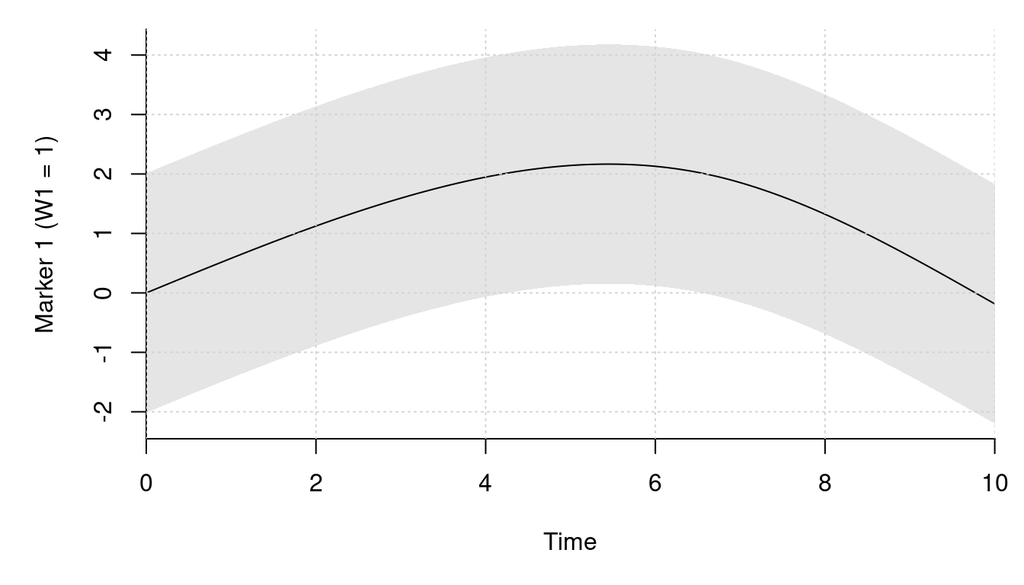

```r
# settings for the simulation
library(splines)
g_funcs <- list(
  function(x, data)
    cbind(ns(x, knots = c(3.33, 6.67), Boundary.knots = c(0, 10)),
          # a time-varying fixed effect
          x * data$W1),
  function(x, data)
    cbind(outer(x, 1:2, `^`),
          # a time-varying fixed effect
          outer(x, 1:2, `^`) * data$W2))
m_funcs <- list(
  function(x, data)
    cbind(
      # a random intercept
      outer(x, 0, `^`),
      # random slope
      data$W1),
  function(x, data)
    cbind(outer(x, 0:1, `^`),
          # a time-varying random effect
          outer(x, 0:1, `^`) * data$W2))

fixef_vary_marker <- list(c(1.4, 1.2, -2.1, .1), c(.5, -.02, .25, -.1)) # beta
fixef_marker <- list(c(-.5, 2, 1), c(1, -1)) # gamma

# Psi
vcov_vary <-
  structure(c(
    0.622, -0.02, 0.13, -0.081, -0.103, 0.016, -0.02, 0.473, 0.121, 0.022, -0.032, 0.059, 0.13, 0.121, 0.801, -0.009, -0.193, 0, -0.081, 0.022, -0.009, 0.529, 0.04, 0.05, -0.103, -0.032, -0.193, 0.04, 0.636, -0.144, 0.016, 0.059, 0, 0.05, -0.144, 0.354), dim = c(6L, 6L))
vcov_marker <- matrix(c(.6^2, .1, .1, .4^2), 2)

# plot the markers' mean curve
library(VAJointSurv)
par(mar = c(5, 5, 1, 1))
rng_basis_one <- stacked_term(
  poly_term(degree = 0, intercept = TRUE, raw = TRUE),
  poly_term(degree = 0, intercept = TRUE, raw = TRUE) |>
    weighted_term(W1))

show_marker_one <- \(newdata, ylab)
  plot_marker(
    time_fixef = stacked_term(
      ns_term(
        knots = c(3.33, 6.67), Boundary.knots = c(0, 10), intercept = FALSE),
      poly_term(degree = 1, raw = TRUE) |>
        weighted_term(W1)),
    time_rng = rng_basis_one,
    fixef_vary = fixef_vary_marker[[1]], x_range = c(0, 10),
    vcov_vary = vcov_vary[1:2, 1:2], ylab = ylab, newdata = newdata)

show_marker_one(data.frame(W1 = 1), ylab = "Marker 1 (W1 = 1)")
```

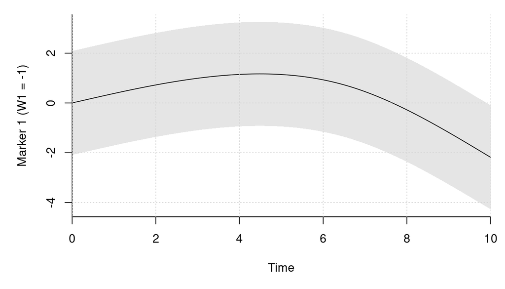

```r
show_marker_one(data.frame(W1 = -1), ylab = "Marker 1 (W1 = -1)")
```

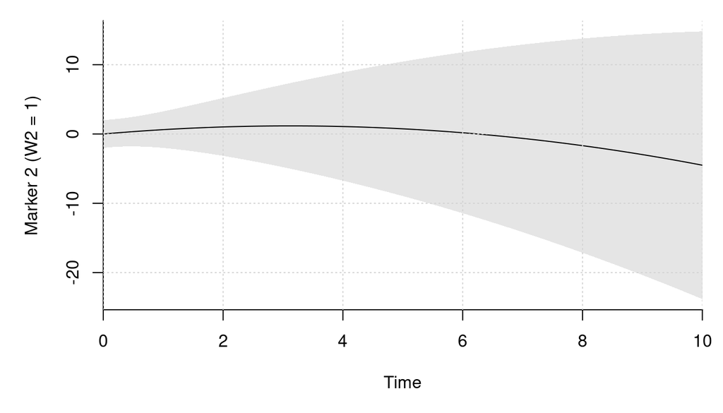

```r
rng_basis_two <- stacked_term(
  poly_term(degree = 1, raw = TRUE, intercept = TRUE),
  poly_term(degree = 1, raw = TRUE, intercept = TRUE) |>
    weighted_term(W2))

show_marker_two <- \(newdata, ylab)
  plot_marker(
    time_fixef = stacked_term(
      poly_term(degree = 2, raw = TRUE),
      poly_term(degree = 2, raw = TRUE)|>
        weighted_term(W2)),
    time_rng = rng_basis_two,
    fixef_vary = fixef_vary_marker[[2]], x_range = c(0, 10),
    vcov_vary = vcov_vary[3:6, 3:6], ylab = ylab, newdata = newdata)

show_marker_two(data.frame(W2 = 1), ylab = "Marker 2 (W2 = 1)")
```

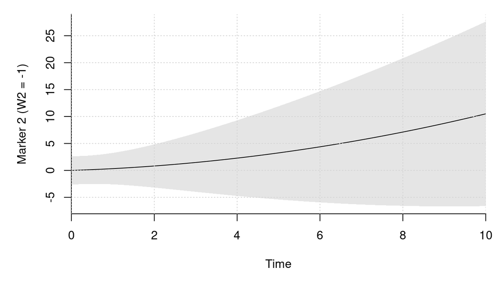

```r
show_marker_two(data.frame(W2 = -1), ylab = "Marker 2 (W2 = -1)")
```

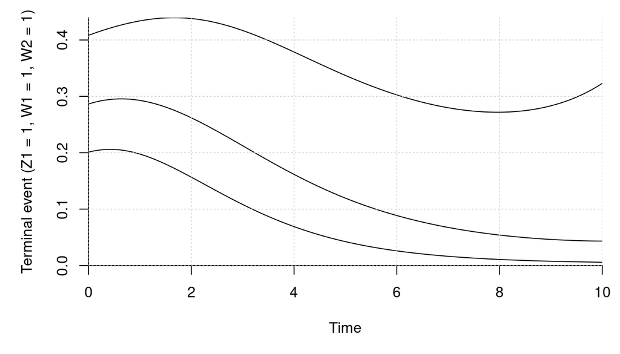

```r
# the survival parameters
vcov_surv <- matrix(c(.2^2, .15^2, .15^2, .25^2), 2) # Xi

fixef_surv <- list(c(-1.25, .25), .75)
associations <- list(c(.4, -.3), c(-.5, .2))
fixef_vary_surv <- list(c(.5, .1, -.2, .11, -.2),
                          c(-1, -.25))

b_funcs <- list(
  function(x, data)
    cbind(bs(x, knots = 5, Boundary.knots = c(0, 10)),
          data$Z1 * x),
  function(x, data) ns(x, knots = 5, Boundary.knots = c(0, 10)))

# plot the log hazard with the 25%, 50% and 75% quantiles
library(SimSurvNMarker)

plot_terminal <- \(newdata, ylab)
  plot_surv(
    time_fixef = stacked_term(
      bs_term(knots = 5, Boundary.knots = c(0, 10)),
      poly_term(degree = 1, raw = TRUE) |>
        weighted_term(Z1)),
    time_rng = list(rng_basis_one, rng_basis_two),
    x_range = c(0, 10), fixef_vary = fixef_vary_surv[[1]],
    vcov_vary = vcov_vary, frailty_var = vcov_surv[1, 1], ps = c(.25, .5, .75),
    associations = associations[[1]], log_hazard_shift = fixef_surv[[1]][1],
    ylab = ylab, newdata = newdata)

plot_terminal(data.frame(Z1 = 1, W1 = 1, W2 = 1),
              "Terminal event (Z1 = 1, W1 = 1, W2 = 1)")
```

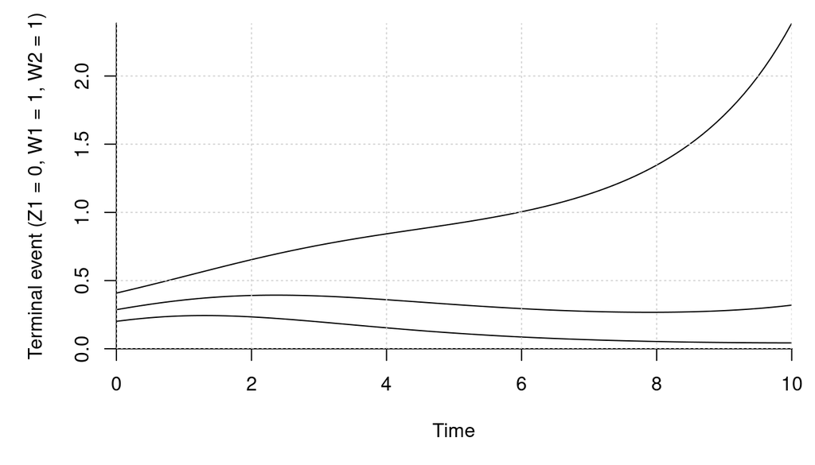

```r
plot_terminal(data.frame(Z1 = 0, W1 = 1, W2 = 1),
              "Terminal event (Z1 = 0, W1 = 1, W2 = 1)")
```

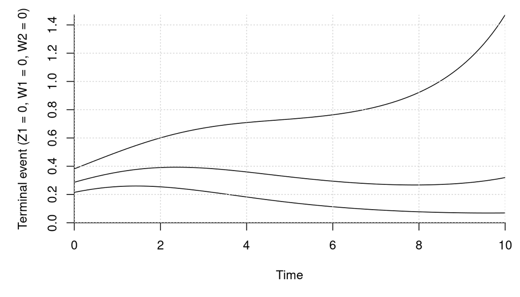

```r
plot_terminal(data.frame(Z1 = 0, W1 = 0, W2 = 0),
              "Terminal event (Z1 = 0, W1 = 0, W2 = 0)")
```

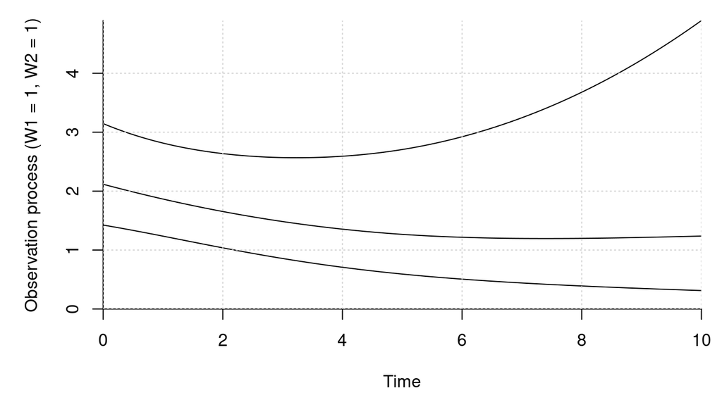

```r
plot_recurrent <- \(newdata, ylab)
  plot_surv(
    time_fixef = ns_term(knots = 5, Boundary.knots = c(0, 10)),
    time_rng = list(rng_basis_one, rng_basis_two),
    x_range = c(0, 10), fixef_vary = fixef_vary_surv[[2]],
    vcov_vary = vcov_vary, frailty_var = vcov_surv[2, 2], ps = c(.25, .5, .75),
    associations = associations[[2]], log_hazard_shift = fixef_surv[[2]][1],
    ylab = ylab, newdata = newdata)

plot_recurrent(
  data.frame(W1 = 1, W2 = 1), "Observation process (W1 = 1, W2 = 1)")
```

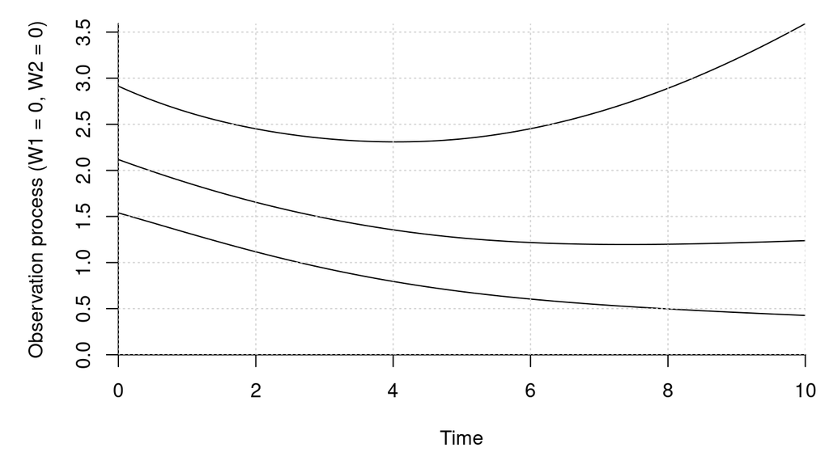

```r
plot_recurrent(
  data.frame(W1 = 0, W2 = 0), "Observation process (W1 = 0, W2 = 0)")
```

```r
library(mvtnorm)
# simulates from the model by sampling a given number of individuals
sim_dat <- function(n_ids){
  # simulate the outcomes
  gl_dat <- get_gl_rule(100L)
  dat <- lapply(1:n_ids, function(id){
    # sample the terminal event time and the censoring time
    cens <- min(rexp(1, rate = 1/10), 10)
    U <- drop(rmvnorm(1, sigma = vcov_vary))

    frailties <- drop(rmvnorm(1, sigma = vcov_surv))
    Z1 <- c(1, runif(1, -1, 1))
    W1 <- runif(1, -1, 1)
    W2 <- runif(1, -1, 1)
    data_pass <- data.frame(Z1 = Z1[2], W1 = W1, W2 = W2)
    log_haz_offset <- sum(Z1 * fixef_surv[[1]]) + frailties[1]

    # assign the conditional survival function
    expansion <- function(x, b_func)
      cbind(b_func(x, data_pass),
            m_funcs[[1]](x, data_pass) %*% U[1:2],
            m_funcs[[2]](x, data_pass) %*% U[3:6])
    surv_func <- function(ti, fixef_vary_surv, associations, b_func){
      formals(expansion)$b_func <- b_func
      eval_surv_base_fun(
        ti = ti, omega = c(fixef_vary_surv, associations), b_func = expansion,
        gl_dat = gl_dat, delta = log_haz_offset)
    }

    # sample the survival time
    rng <- runif(1)
    root_func <- function(x, rng)
      rng - surv_func(x, fixef_vary_surv = fixef_vary_surv[[1]],
                      associations = associations[[1]], b_func = b_funcs[[1]])

    if(root_func(cens, rng) < 0){
      # the observation is censored
      y_terminal <- cens
      event <- 0
    } else {
      # find the event time
      root <- uniroot(root_func, c(0, cens), tol = 1e-6, rng = rng)
      y_terminal <- root$root
      event <- 1

    }

    terminal_outcome <- cbind(y = y_terminal, event = event, Z1 = Z1[2],
                              id = id, W1 = W1, W2 = W2)

    # clean up
    rm(list = setdiff(
      ls(),
      c("y_terminal", "terminal_outcome", "expansion", "surv_func", "frailties",
        "U", "id", "data_pass", "W1", "W2")))

    # simulate the observation times
    Z2 <- 1
    log_haz_offset <- sum(Z2 * fixef_surv[[2]]) + frailties[2]

    root_func <- function(x, left_trunc_surv, rng)
      rng - surv_func(x, fixef_vary_surv = fixef_vary_surv[[2]],
                      associations = associations[[2]], b_func = b_funcs[[2]]) /
      left_trunc_surv

    max_sample <- 1000L
    left_trunc_surv <- 1
    Z2 <- matrix(rep(Z2, each = max_sample), max_sample)
    event <- y <- lf_trunc <- rep(NA_real_, max_sample)
    lf_trunc_i <- 0
    for(i in 1:max_sample){
      # sample a random uniform variable and invert the survival function
      rng_i <- runif(1)
      lf_trunc[i] <- lf_trunc_i

      if(root_func(y_terminal, left_trunc_surv, rng_i) < 0){
        # the observation is right-censored and we can exit
        y[i] <- y_terminal
        event[i] <- 0
        break
      }

      # we need to invert the survival function to find the observation time
      root <- uniroot(root_func, c(lf_trunc_i, y_terminal), tol = 1e-6,
                      left_trunc_surv = left_trunc_surv, rng = rng_i)
      lf_trunc_i <- y[i] <- root$root
      event[i] <- 1
      left_trunc_surv <- surv_func(
        y[i], fixef_vary_surv = fixef_vary_surv[[2]], associations = associations[[2]],
        b_func = b_funcs[[2]])
    }

    colnames(Z2) <- paste0("Z", 1:NCOL(Z2) - 1L)
    obs_process <- cbind(lf_trunc = lf_trunc[1:i], y = y[1:i],
                         event = event[1:i], Z2[1:i, -1, drop = FALSE],
                         id = id, W1 = W1, W2 = W2)

    # clean up
    rm(list = setdiff(
      ls(),
      c("terminal_outcome", "U", "id", "obs_process", "data_pass", "W1", "W2")))

    # sample the fixed effect covariates
    obs_time <- c(0, obs_process[obs_process[, "event"] == 1, "y"])
    n_obs <- length(obs_time)
    X1 <- cbind(1, rnorm(n_obs), W1)
    X2 <- cbind(matrix(1, n_obs), W2)
    colnames(X1) <- paste0("X1_", 1:NCOL(X1) - 1L)
    colnames(X1)[NCOL(X1)] <- "W1"
    colnames(X2) <- paste0("X2_", 1:NCOL(X2) - 1L)
    colnames(X2)[NCOL(X2)] <- "W2"
    X <- list(X1, X2)

    # sample the outcomes
    eta <- sapply(1:2, function(i)
      X[[i]] %*% fixef_marker[[i]] +
        drop(g_funcs[[i]](obs_time, data_pass)) %*% fixef_vary_marker[[i]] +
        drop(m_funcs[[i]](obs_time, data_pass)) %*% U[if(i == 1) 1:2 else 3:6])

    ys <- eta + rmvnorm(n_obs, sigma = vcov_marker)
    colnames(ys) <- paste0("Y", 1:2)

    # mask some observations
    do_mask <- sample.int(3L, n_obs, replace = TRUE)
    ys[do_mask == 2, 1] <- NA
    ys[do_mask == 3, 2] <- NA

    X <- do.call(cbind, lapply(X, function(x) x[, -1, drop = FALSE]))
    marker_data <- cbind(ys, X, time = obs_time, id = id)

    return(list(marker_data = marker_data, obs_process = obs_process,
                terminal_outcome = terminal_outcome))
  })

  # combine the data and return
  marker_data <- as.data.frame(do.call(
    rbind, lapply(dat, `[[`, "marker_data")))
  marker_data$id <- as.integer(marker_data$id)
  # the order does not matter
  marker_data <- marker_data[sample.int(NROW(marker_data)), ]

  obs_process <- as.data.frame(do.call(
    rbind, lapply(dat, `[[`, "obs_process")))
  obs_process$id <- as.integer(obs_process$id)
  # the order does not matter
  obs_process <- obs_process[sample.int(NROW(obs_process)), ]

  terminal_outcome <- as.data.frame(do.call(
    rbind, lapply(dat, `[[`, "terminal_outcome")))
  terminal_outcome$id <- as.integer(terminal_outcome$id)
  # the order does not matter
  terminal_outcome <- terminal_outcome[sample.int(NROW(terminal_outcome)), ]

  list(marker_data = marker_data, obs_process = obs_process,
       terminal_outcome = terminal_outcome)
}

# sample a moderately large data set
set.seed(2)
dat <- sim_dat(1000L)

# we show a few properties of the data below
mean(dat$terminal_outcome$event) # mean event rate
```

```
#> [1] 0.713
```

```r
sum(dat$obs_process$event) # number of observed markers less the individuals
```

```
#> [1] 6919
```

```r
NROW(dat$marker_data) # number of observed markers less the individuals
```

```
#> [1] 7919
```

```r
# distribution of observed marker per individual
proportions(table(table(dat$obs_process$id)))
```

```
#>
#>     1     2     3     4     5     6     7     8     9    10    11    12    13
#> 0.214 0.161 0.121 0.102 0.069 0.062 0.039 0.040 0.024 0.019 0.018 0.018 0.010
#>    14    15    16    17    18    19    20    21    22    23    24    25    27
#> 0.007 0.008 0.005 0.002 0.008 0.004 0.005 0.002 0.004 0.004 0.002 0.004 0.002
#>    28    29    30    31    32    33    38    39    40    41    43    45    46
#> 0.005 0.005 0.001 0.003 0.001 0.002 0.001 0.001 0.003 0.001 0.002 0.001 0.001
#>    49    54    58    63    66    72    77    81    82    84    98   119   135
#> 0.001 0.001 0.001 0.001 0.001 0.002 0.001 0.001 0.001 0.001 0.001 0.001 0.001
#>   172   220   247   288   318
#> 0.001 0.001 0.001 0.001 0.001
```

```r
# show data for one individual
subset(dat$marker_data, id == 1)
```

```
#>         Y1    Y2    X1_1      W1    W2   time id
#> X.1     NA 3.894 -1.1152 -0.1104 -0.85 0.3592  1
#> X   -1.462 2.890 -0.3663 -0.1104 -0.85 0.0000  1
#> X.4  2.027 6.237  0.3244 -0.1104 -0.85 1.4799  1
#> X.3     NA 5.071  1.1210 -0.1104 -0.85 1.1119  1
#> X.2 -1.951 4.066 -0.9756 -0.1104 -0.85 0.4256  1
#> X.5     NA 6.153 -0.5684 -0.1104 -0.85 1.7229  1
```

```r
subset(dat$obs_process, id == 1)
```

```
#>   lf_trunc      y event id      W1    W2
#> 1   0.0000 0.3592     1  1 -0.1104 -0.85
#> 6   1.7229 2.2592     0  1 -0.1104 -0.85
#> 2   0.3592 0.4256     1  1 -0.1104 -0.85
#> 3   0.4256 1.1119     1  1 -0.1104 -0.85
#> 4   1.1119 1.4799     1  1 -0.1104 -0.85
#> 5   1.4799 1.7229     1  1 -0.1104 -0.85
```

```r
subset(dat$terminal_outcome, id == 1)
```

```
#>       y event      Z1 id      W1    W2
#> 1 2.259     1 -0.5483  1 -0.1104 -0.85
```

```r
# estimate the model with this package. Get the object we need for the
# optimization
marker_1 <- marker_term(
  Y1 ~ X1_1 + W1, id = id, subset(dat$marker_data, !is.na(Y1)),
  time_fixef =
    stacked_term(
      ns_term(time, knots = c(3.33, 6.67), Boundary.knots = c(0, 10)),
      poly_term(time, degree = 1, raw = TRUE) |>
        weighted_term(W1)),
  time_rng =
    stacked_term(
      poly_term(time, degree = 0, intercept = TRUE, raw = TRUE),
      poly_term(time, degree = 0, intercept = TRUE, raw = TRUE) |>
        weighted_term(W1)))

marker_2 <- marker_term(
  Y2 ~ W2, id = id, subset(dat$marker_data, !is.na(Y2)),
  time_fixef =
    stacked_term(
      poly_term(time, degree = 2, raw = TRUE),
      poly_term(time, degree = 2, raw = TRUE) |>
        weighted_term(W2)),
  time_rng =
    stacked_term(
      poly_term(time, degree = 1, raw = TRUE, intercept = TRUE),
      poly_term(time, degree = 1, raw = TRUE, intercept = TRUE) |>
        weighted_term(W2)))

library(survival)
surv_terminal <- surv_term(
  Surv(y, event) ~ Z1, id = id, dat$terminal_outcome,
  time_fixef =
    stacked_term(
      bs_term(y, knots = 5, Boundary.knots = c(0, 10)),
      poly_term(y, degree = 1, raw = TRUE) |>
        weighted_term(Z1)),
  with_frailty = TRUE)
surv_obs <- surv_term(
  Surv(lf_trunc, y, event) ~ 1, id = id, dat$obs_process,
  time_fixef = ns_term(y, knots = 5, Boundary.knots = c(0, 10)),
  with_frailty = TRUE)

comp_obj <- joint_ms_ptr(markers = list(marker_1, marker_2),
                         survival_terms = list(surv_terminal, surv_obs),
                         max_threads = 4L)
rm(marker_1, marker_2, surv_terminal, surv_obs)

# get the starting values
system.time(start_val <- joint_ms_start_val(comp_obj, gr_tol = .1))
# lower bound at the starting values
print(-attr(start_val, "value"), digits = 8)
```

```
#> [1] -8865.4428
```

```r
# check that the gradient is correct
f <- function(x){
  start_val[seq_along(x)] <- x
  joint_ms_lb(comp_obj, start_val)
}

all.equal(numDeriv::grad(f, head(start_val, 53 + 2 * 44)),
          head(joint_ms_lb_gr(comp_obj, start_val), 53 + 2 * 44),
          tolerance = 1e-6)
```

```
#> [1] TRUE
```

```r
# find the maximum lower bound estimate
system.time(opt_out <- joint_ms_opt(
  comp_obj, par = start_val, max_it = 10000L, pre_method = 3L,
  cg_tol = .1, c2 = .1, gr_tol = .1))
```

```
#>    user  system elapsed
#> 771.851   0.408 195.882
```

```r
# we set gr_tol in the call so this is the convergence criterion for the
# gradient
sqrt(sum(joint_ms_lb_gr(comp_obj, opt_out$par)^2))
```

```
#> [1] 0.08981
```

```r
opt_out$info # convergence code (0 == 'OK')
```

```
#> [1] 0
```

```r
print(-opt_out$value, digits = 8) # maximum lower bound value
```

```
#> [1] -7333.7229
```

```r
opt_out$counts
```

```
#> function gradient     n_cg
#>     2508     1835    17924
```

```r
# compare the estimates with the actual values. Start with the fixed effects
fmt_ests <- joint_ms_format(comp_obj, opt_out$par)

# the parameters for the first marker
fmt_ests$markers[[1]]
```

```
#> $fixef
#>
#> -0.5297  1.9959  1.0058
#>
#> $fixef_vary
#>
#>  1.3503  1.3160 -2.0364  0.1038
```

```r
fixef_marker[[1]] # true values
```

```
#> [1] -0.5  2.0  1.0
```

```r
fixef_vary_marker[[1]] # true values
```

```
#> [1]  1.4  1.2 -2.1  0.1
```

```r
# the parameters for the second marker
fmt_ests$markers[[2]]
```

```
#> $fixef
#>
#>  1.004 -1.030
#>
#> $fixef_vary
#>
#>  0.57345 -0.02072  0.30081 -0.10075
```

```r
fixef_marker[[2]] # true values
```

```
#> [1]  1 -1
```

```r
fixef_vary_marker[[2]] # true values
```

```
#> [1]  0.50 -0.02  0.25 -0.10
```

```r
# the fixed effects for the survival outcome and the association parameters
# for the terminal event
fmt_ests$survival[[1]]
```

```
#> $fixef
#>
#> -1.2353  0.2632
#>
#> $fixef_vary
#>
#>  0.8067 -0.3803 -0.8106  0.1701 -0.1939
#>
#> $associations
#>
#>  0.2831 -0.2842
```

```r
fixef_surv[[1]]
```

```
#> [1] -1.25  0.25
```

```r
fixef_vary_surv[[1]]
```

```
#> [1]  0.50  0.10 -0.20  0.11 -0.20
```

```r
associations[[1]]
```

```
#> [1]  0.4 -0.3
```

```r
# same for the observation process
fmt_ests$survival[[2]]
```

```
#> $fixef
#>
#> 0.7519
#>
#> $fixef_vary
#>
#> -0.8182 -0.1391
#>
#> $associations
#>
#> -0.5121  0.1978
```

```r
fixef_surv[[2]]
```

```
#> [1] 0.75
```

```r
fixef_vary_surv[[2]]
```

```
#> [1] -1.00 -0.25
```

```r
associations[[2]]
```

```
#> [1] -0.5  0.2
```

```r
# the parameters for covariance matrix of the random effects
fmt_ests$vcov$vcov_vary
```

```
#>          [,1]     [,2]     [,3]      [,4]     [,5]      [,6]
#> [1,]  0.71220 -0.08031  0.20699 -0.105911 -0.09079 -0.026239
#> [2,] -0.08031  0.45789  0.05584 -0.059417  0.03967 -0.012826
#> [3,]  0.20699  0.05584  0.89696 -0.142425 -0.09388  0.068093
#> [4,] -0.10591 -0.05942 -0.14242  0.448486  0.02705  0.006592
#> [5,] -0.09079  0.03967 -0.09388  0.027049  0.17862  0.070847
#> [6,] -0.02624 -0.01283  0.06809  0.006592  0.07085  0.480699
```

```r
vcov_vary # the true values
```

```
#>        [,1]   [,2]   [,3]   [,4]   [,5]   [,6]
#> [1,]  0.622 -0.020  0.130 -0.081 -0.103  0.016
#> [2,] -0.020  0.473  0.121  0.022 -0.032  0.059
#> [3,]  0.130  0.121  0.801 -0.009 -0.193  0.000
#> [4,] -0.081  0.022 -0.009  0.529  0.040  0.050
#> [5,] -0.103 -0.032 -0.193  0.040  0.636 -0.144
#> [6,]  0.016  0.059  0.000  0.050 -0.144  0.354
```

```r
# the parameters for the error term covariance matrix
fmt_ests$vcov$vcov_marker
```

```
#>        [,1]   [,2]
#> [1,] 0.3805 0.1128
#> [2,] 0.1128 0.1673
```

```r
vcov_marker
```

```
#>      [,1] [,2]
#> [1,] 0.36 0.10
#> [2,] 0.10 0.16
```

```r
# the parameters for the frailty covariance matrix
fmt_ests$vcov$vcov_surv
```

```
#>         [,1]    [,2]
#> [1,] 0.02250 0.03248
#> [2,] 0.03248 0.05625
```

```r
vcov_surv
```

```
#>        [,1]   [,2]
#> [1,] 0.0400 0.0225
#> [2,] 0.0225 0.0625
```

### Two Markers, the Observation Time Process, a Terminal Event, and Mixed Dependencies

We simulate and fit a model in this section where we have two markers, a recurrent event which is the observation times, and a terminal event like in the previous section. Unlike in the previous section, we let the two time-to-event outcomes depend on the integral or derivative of the deviation of the mean marker and the current value.

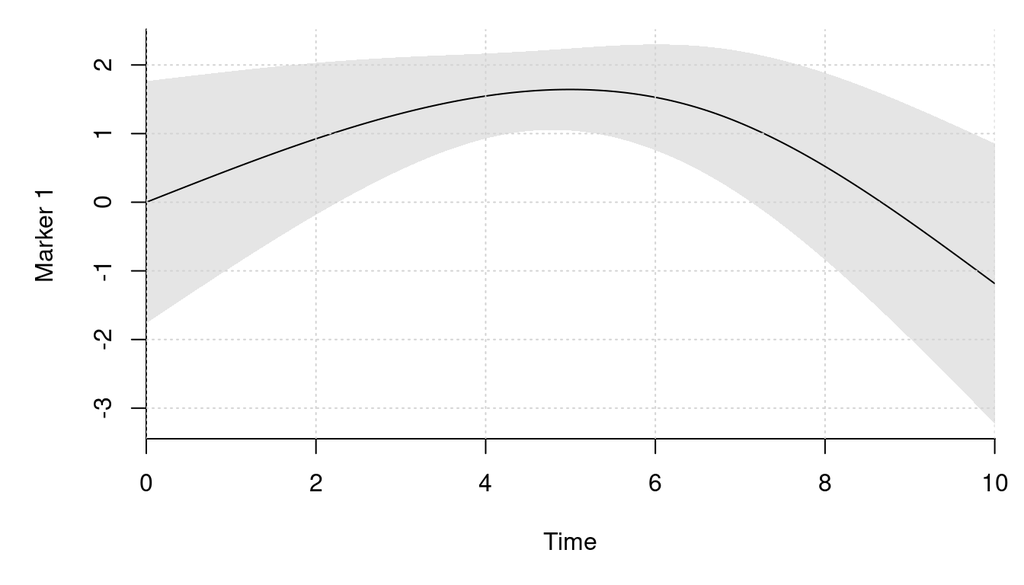

```r
# settings for the simulation
library(VAJointSurv)
g1 <- ns_term(knots = c(3.33, 6.67), Boundary.knots = c(0, 10))
g2 <- poly_term(degree = 2, raw = TRUE)
g_funcs <- list(g1$eval, g2$eval)

m1 <- ns_term(knots = numeric(), Boundary.knots = c(0, 10), intercept = TRUE)
m2 <- poly_term(degree = 1, intercept = TRUE, raw = TRUE)
m_funcs <- list(m1$eval, m2$eval)

fixef_vary_marker <- list(c(1.4, 1.2, -2.1), c(.5, -.02)) # beta
fixef_marker <- list(c(-.5, 2), 1) # gamma

# Psi
vcov_vary <- structure(c(0.35, 0.08, -0.05, 0.01, 0.08, 1.92, -0.24, -0.04,
                   -0.05, -0.24, 0.32, 0.09, 0.01, -0.04, 0.09, 0.12),
                 .Dim = c(4L, 4L))
vcov_marker <- matrix(c(.6^2, .1, .1, .4^2), 2)

# plot the markers' mean curve
par(mar = c(5, 5, 1, 1))
plot_marker(
  time_fixef = g1, time_rng = m1,
  fixef_vary = fixef_vary_marker[[1]], x_range = c(0, 10),
  vcov_vary = vcov_vary[1:2, 1:2], ylab = "Marker 1")
```

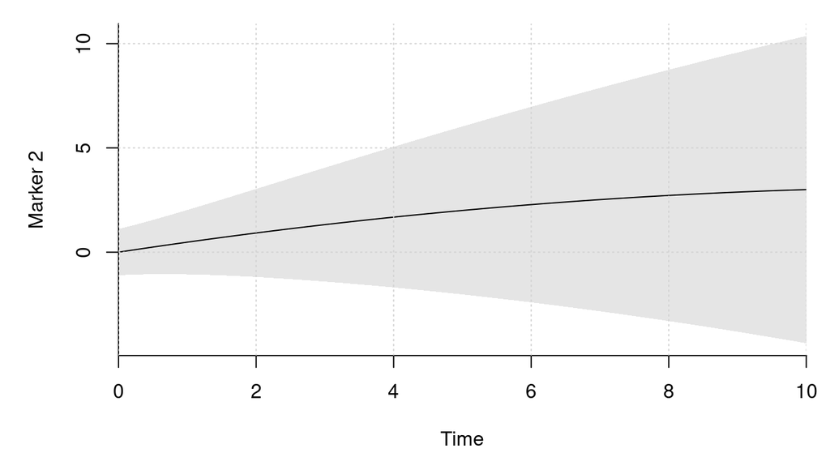

```r
plot_marker(
  time_fixef = g2, time_rng = m2,
  fixef_vary = fixef_vary_marker[[2]], x_range = c(0, 10),
  vcov_vary = vcov_vary[3:4, 3:4], ylab = "Marker 2")
```

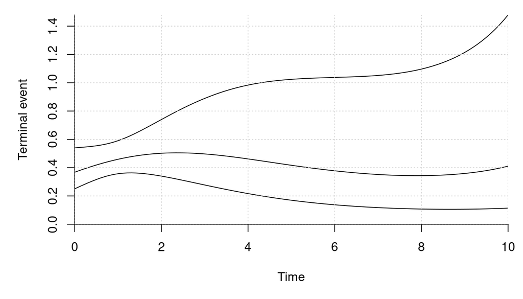

```r
# the survival parameters
vcov_surv <- matrix(c(.2^2, .15^2, .15^2, .25^2), 2) # Xi

fixef_surv <- list(c(-1, .25), .2)
# needs more parameters now
associations <- list(c(-.4, .6, -.4), c(-.7, .2, -1))
fixef_vary_surv <- list(c(.5, .1, -.2, .11),
                          c(-1, -.25))

# specify the dependence with the random effect from the markers
ders <- list(
  list(c(-1L, 0L), # cumulative and present value
       0L),        # present value
  list(0L,         # present value
       c(0L, 1L))) # present value and derivative

b_funcs <- list(
  function(x) bs(x, knots = 5, Boundary.knots = c(0, 10)),
  function(x) ns(x, knots = 5, Boundary.knots = c(0, 10)))

# plot the log hazard with the 25%, 50% and 75% quantiles
library(SimSurvNMarker)

plot_surv(
  time_fixef = bs_term(knots = 5, Boundary.knots = c(0, 10)),
  time_rng = list(m1, m2), ders = ders[[1]],
  x_range = c(0, 10), fixef_vary = fixef_vary_surv[[1]],
  vcov_vary = vcov_vary, frailty_var = vcov_surv[1, 1], ps = c(.25, .5, .75),
  associations = associations[[1]], log_hazard_shift = fixef_surv[[1]][1],
  ylab = "Terminal event")
```

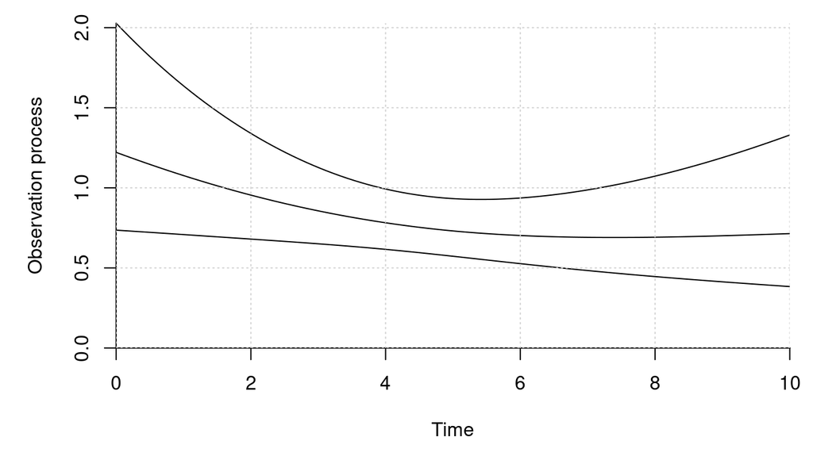

```r
plot_surv(
  time_fixef = ns_term(knots = 5, Boundary.knots = c(0, 10)),
  time_rng = list(m1, m2), ders = ders[[2]],
  x_range = c(0, 10), fixef_vary = fixef_vary_surv[[2]],
  vcov_vary = vcov_vary, frailty_var = vcov_surv[2, 2], ps = c(.25, .5, .75),
  associations = associations[[2]], log_hazard_shift = fixef_surv[[2]][1],
  ylab = "Observation process")
```

```r
library(mvtnorm)
# simulates from the model by sampling a given number of individuals
sim_dat <- function(n_ids){
  # simulate the outcomes
  gl_dat <- get_gl_rule(100L)
  dat <- lapply(1:n_ids, function(id){
    # sample the terminal event time and the censoring time
    cens <- min(rexp(1, rate = 1/10), 10)
    U <- drop(rmvnorm(1, sigma = vcov_vary))

    frailties <- drop(rmvnorm(1, sigma = vcov_surv))
    Z1 <- c(1, runif(1, -1, 1))
    log_haz_offset <- sum(Z1 * fixef_surv[[1]]) + frailties[1]

    # assign the conditional survival function
    expansion <- function(x, b_func)
      cbind(b_func(x),
            t(U[1:2] %*% m_funcs[[1]](x, ders[[1]][[1]][1])),
            t(U[1:2] %*% m_funcs[[1]](x, ders[[1]][[1]][2])),
            t(U[3:4] %*% m_funcs[[2]](x, ders[[1]][[2]][1])))
    surv_func <- function(ti, fixef_vary_surv, associations, b_func){
      formals(expansion)$b_func <- b_func
      eval_surv_base_fun(
        ti = ti, omega = c(fixef_vary_surv, associations), b_func = expansion,
        gl_dat = gl_dat, delta = log_haz_offset)
    }

    # sample the survival time
    rng <- runif(1)
    root_func <- function(x, rng)
      rng - surv_func(x, fixef_vary_surv = fixef_vary_surv[[1]],
                      associations = associations[[1]], b_func = b_funcs[[1]])

    if(root_func(cens, rng) < 0){
      # the observation is censored
      y_terminal <- cens
      event <- 0
    } else {
      # find the event time
      root <- uniroot(root_func, c(0, cens), tol = 1e-6, rng = rng)
      y_terminal <- root$root
      event <- 1

    }

    terminal_outcome <- cbind(y = y_terminal, event = event, Z1 = Z1[2],
                              id = id)

    # clean up
    rm(list = setdiff(ls(), c("y_terminal", "terminal_outcome", "expansion",
                              "surv_func", "frailties", "U", "id")))

    # simulate the observation times
    Z2 <- 1
    log_haz_offset <- sum(Z2 * fixef_surv[[2]]) + frailties[2]

    expansion <- function(x, b_func)
      cbind(b_func(x),
            t(U[1:2] %*% m_funcs[[1]](x, ders[[2]][[1]][1])),
            t(U[3:4] %*% m_funcs[[2]](x, ders[[2]][[2]][1])),
            t(U[3:4] %*% m_funcs[[2]](x, ders[[2]][[2]][2])))
    root_func <- function(x, left_trunc_surv, rng)
      rng - surv_func(x, fixef_vary_surv = fixef_vary_surv[[2]],
                      associations = associations[[2]], b_func = b_funcs[[2]]) /
      left_trunc_surv

    max_sample <- 1000L
    left_trunc_surv <- 1
    Z2 <- matrix(rep(Z2, each = max_sample), max_sample)
    event <- y <- lf_trunc <- rep(NA_real_, max_sample)
    lf_trunc_i <- 0
    for(i in 1:max_sample){
      # sample a random uniform variable and invert the survival function
      rng_i <- runif(1)
      lf_trunc[i] <- lf_trunc_i

      if(root_func(y_terminal, left_trunc_surv, rng_i) < 0){
        # the observation is right-censored and we can exit
        y[i] <- y_terminal
        event[i] <- 0
        break
      }

      # we need to invert the survival function to find the observation time
      root <- uniroot(root_func, c(lf_trunc_i, y_terminal), tol = 1e-6,
                      left_trunc_surv = left_trunc_surv, rng = rng_i)
      lf_trunc_i <- y[i] <- root$root
      event[i] <- 1
      left_trunc_surv <- surv_func(
        y[i], fixef_vary_surv = fixef_vary_surv[[2]], associations = associations[[2]],
        b_func = b_funcs[[2]])
    }

    colnames(Z2) <- paste0("Z", 1:NCOL(Z2) - 1L)
    obs_process <- cbind(lf_trunc = lf_trunc[1:i], y = y[1:i],
                         event = event[1:i], Z2[1:i, -1, drop = FALSE],
                         id = id)

    # clean up
    rm(list = setdiff(ls(), c("terminal_outcome", "U", "id",
                              "obs_process")))

    # sample the fixed effect covariates
    obs_time <- c(0, obs_process[obs_process[, "event"] == 1, "y"])
    n_obs <- length(obs_time)
    X1 <- cbind(1, rnorm(n_obs))
    X2 <- matrix(1, n_obs)
    colnames(X1) <- paste0("X1_", 1:NCOL(X1) - 1L)
    colnames(X2) <- paste0("X2_", 1:NCOL(X2) - 1L)
    X <- list(X1, X2)

    # sample the outcomes
    eta <- sapply(1:2, function(i)
      X[[i]] %*% fixef_marker[[i]] +
        drop(t(g_funcs[[i]](obs_time))) %*% fixef_vary_marker[[i]] +
        drop(t(m_funcs[[i]](obs_time))) %*% U[1:2 + (i == 2) * 2])

    ys <- eta + rmvnorm(n_obs, sigma = vcov_marker)
    colnames(ys) <- paste0("Y", 1:2)

    # mask some observations
    do_mask <- sample.int(3L, n_obs, replace = TRUE)
    ys[do_mask == 2, 1] <- NA
    ys[do_mask == 3, 2] <- NA

    X <- do.call(cbind, lapply(X, function(x) x[, -1, drop = FALSE]))
    marker_data <- cbind(ys, X, time = obs_time, id = id)

    return(list(marker_data = marker_data, obs_process = obs_process,
                terminal_outcome = terminal_outcome))
  })

  # combine the data and return
  marker_data <- as.data.frame(do.call(
    rbind, lapply(dat, `[[`, "marker_data")))
  marker_data$id <- as.integer(marker_data$id)
  # the order does not matter
  marker_data <- marker_data[sample.int(NROW(marker_data)), ]

  obs_process <- as.data.frame(do.call(
    rbind, lapply(dat, `[[`, "obs_process")))
  obs_process$id <- as.integer(obs_process$id)
  # the order does not matter
  obs_process <- obs_process[sample.int(NROW(obs_process)), ]

  terminal_outcome <- as.data.frame(do.call(
    rbind, lapply(dat, `[[`, "terminal_outcome")))
  terminal_outcome$id <- as.integer(terminal_outcome$id)
  # the order does not matter
  terminal_outcome <- terminal_outcome[sample.int(NROW(terminal_outcome)), ]

  list(marker_data = marker_data, obs_process = obs_process,
       terminal_outcome = terminal_outcome)
}

# sample a moderately large data set
set.seed(2)
dat <- sim_dat(1000L)

# we show a few properties of the data below
mean(dat$terminal_outcome$event) # mean event rate
```

```
#> [1] 0.77
```

```r
sum(dat$obs_process$event) # number of observed markers less the individuals
```

```
#> [1] 2425
```

```r
NROW(dat$marker_data) # number of observed markers less the individuals
```

```
#> [1] 3425
```

```r
# distribution of observed marker per individual
proportions(table(table(dat$obs_process$id)))
```

```
#>
#>     1     2     3     4     5     6     7     8     9    10    11    12    13
#> 0.319 0.190 0.141 0.109 0.078 0.041 0.033 0.027 0.013 0.012 0.015 0.003 0.004
#>    14    16    17    27    29    31    38
#> 0.005 0.003 0.003 0.001 0.001 0.001 0.001
```

```r
# show data for one individual
subset(dat$marker_data, id == 1)
```

```
#>          Y1    Y2     X1_1   time id
#> X.6      NA 8.382 -0.56843 7.8724  1
#> X.3  0.7605    NA -0.97556 3.6495  1
#> X.7 -3.5564 9.325 -1.03442 8.4949  1
#> X.2 -0.5523    NA -1.11525 0.4897  1
#> X.9 -3.9194 9.798 -0.98139 9.5827  1
#> X.1      NA 1.726 -0.36632 0.4271  1
#> X        NA 1.987 -0.02815 0.0000  1
#> X.4  4.1065 6.374  1.12102 4.9005  1
#> X.8 -1.5241 9.405 -0.53302 8.6015  1
#> X.5  0.3933    NA  0.32444 7.5675  1
```

```r
subset(dat$obs_process, id == 1)
```

```
#>    lf_trunc       y event id
#> 8    8.4949  8.6015     1  1
#> 9    8.6015  9.5827     1  1
#> 2    0.4271  0.4897     1  1
#> 1    0.0000  0.4271     1  1
#> 7    7.8724  8.4949     1  1
#> 10   9.5827 10.0000     0  1
#> 5    4.9005  7.5675     1  1
#> 6    7.5675  7.8724     1  1
#> 4    3.6495  4.9005     1  1
#> 3    0.4897  3.6495     1  1
```

```r
subset(dat$terminal_outcome, id == 1)
```

```
#>    y event      Z1 id
#> 1 10     0 -0.6384  1
```

```r
# estimate the model with this package. Get the object we need for the
# optimization
marker_1 <- marker_term(
  Y1 ~ X1_1, id = id, subset(dat$marker_data, !is.na(Y1)),
  time_fixef = ns_term(time, knots = c(3.33, 6.67), Boundary.knots = c(0, 10)),
  time_rng = ns_term(time, knots = numeric(), Boundary.knots = c(0, 10),
                     intercept = TRUE))
marker_2 <- marker_term(
  Y2 ~ 1, id = id, subset(dat$marker_data, !is.na(Y2)),
  time_fixef = poly_term(time, degree = 2, raw = TRUE),
  time_rng = poly_term(time, degree = 1, raw = TRUE, intercept = TRUE))

library(survival)
surv_terminal <- surv_term(
  Surv(y, event) ~ Z1, id = id, dat$terminal_outcome,
  time_fixef = bs_term(y, knots = 5, Boundary.knots = c(0, 10)),
  with_frailty = TRUE)
surv_obs <- surv_term(
  Surv(lf_trunc, y, event) ~ 1, id = id, dat$obs_process,
  time_fixef = ns_term(y, knots = 5, Boundary.knots = c(0, 10)),
  with_frailty = TRUE)

comp_obj <- joint_ms_ptr(markers = list(marker_1, marker_2),
                         survival_terms = list(surv_terminal, surv_obs),
                         max_threads = 4L, ders = ders)
rm(marker_1, marker_2, surv_terminal, surv_obs)

# get the starting values
system.time(start_val <- joint_ms_start_val(comp_obj, gr_tol = .1))
# lower bound at the starting values
print(-attr(start_val, "value"), digits = 8)
```

```
#> [1] -7950.3559
```

```r
# check that the gradient is correct
f <- function(x){
  start_val[seq_along(x)] <- x
  joint_ms_lb(comp_obj, start_val)
}

all.equal(numDeriv::grad(f, head(start_val, 39 + 2 * 27)),
          head(joint_ms_lb_gr(comp_obj, start_val), 39 + 2 * 27),
          tolerance = 1e-6)
```

```
#> [1] TRUE
```

```r
# find the maximum lower bound estimate
system.time(opt_out <- joint_ms_opt(comp_obj, par = start_val, max_it = 1000L,
                                    pre_method = 3L, cg_tol = .2, c2 = .1,
                                    gr_tol = .1))
```

```
#>    user  system elapsed
#> 242.687   0.152  60.773
```

```r
# we set gr_tol in the call so this is the convergence criterion for the
# gradient
sqrt(sum(joint_ms_lb_gr(comp_obj, opt_out$par)^2))
```

```
#> [1] 0.09699
```

```r
opt_out$info # convergence code (0 == 'OK')
```

```
#> [1] 0
```

```r
print(-opt_out$value, digits = 8) # maximum lower bound value
```

```
#> [1] -7596.2613
```

```r
opt_out$counts
```

```
#> function gradient     n_cg
#>     2851     2059    14027
```

```r
# compare the estimates with the actual values. Start with the fixed effects
fmt_ests <- joint_ms_format(comp_obj, opt_out$par)

# the parameters for the first marker
fmt_ests$markers[[1]]
```

```
#> $fixef
#>
#> -0.4302  2.0078
#>
#> $fixef_vary
#>
#>  1.355  1.218 -1.801
```

```r
fixef_marker[[1]] # true values
```

```
#> [1] -0.5  2.0
```

```r
fixef_vary_marker[[1]] # true values
```

```
#> [1]  1.4  1.2 -2.1
```

```r
# the parameters for the second marker
fmt_ests$markers[[2]]
```

```
#> $fixef
#>
#> 0.9901
#>
#> $fixef_vary
#>
#>  0.53124 -0.02203
```

```r
fixef_marker[[2]] # true values
```

```
#> [1] 1
```

```r
fixef_vary_marker[[2]] # true values
```

```
#> [1]  0.50 -0.02
```

```r
# the fixed effects for the survival outcome and the association parameters
# for the terminal event
fmt_ests$survival[[1]]
```

```
#> $fixef
#>
#> -1.0857  0.2989
#>
#> $fixef_vary
#>
#>  0.74032  0.08106 -0.10742 -0.42202
#>
#> $associations
#>
#> -0.4093  0.5460 -0.4314
```

```r
fixef_surv[[1]]
```

```
#> [1] -1.00  0.25
```

```r
fixef_vary_surv[[1]]
```

```
#> [1]  0.50  0.10 -0.20  0.11
```

```r
associations[[1]]
```

```
#> [1] -0.4  0.6 -0.4
```

```r
# same for the observation process
fmt_ests$survival[[2]]
```

```
#> $fixef
#>
#> 0.2204
#>
#> $fixef_vary
#>
#> -1.2801 -0.2923
#>
#> $associations
#>
#> -0.7104  0.1854 -0.7896
```

```r
fixef_surv[[2]]
```

```
#> [1] 0.2
```

```r
fixef_vary_surv[[2]]
```

```
#> [1] -1.00 -0.25
```

```r
associations[[2]]
```

```
#> [1] -0.7  0.2 -1.0
```

```r
# the parameters for covariance matrix of the random effects
fmt_ests$vcov$vcov_vary
```

```
#>          [,1]    [,2]     [,3]     [,4]
#> [1,]  0.34379  0.2413 -0.07381 -0.03167
#> [2,]  0.24130  2.1631 -0.26000 -0.11238
#> [3,] -0.07381 -0.2600  0.27222  0.10383
#> [4,] -0.03167 -0.1124  0.10383  0.12941
```

```r
vcov_vary # the true values
```

```
#>       [,1]  [,2]  [,3]  [,4]
#> [1,]  0.35  0.08 -0.05  0.01
#> [2,]  0.08  1.92 -0.24 -0.04
#> [3,] -0.05 -0.24  0.32  0.09
#> [4,]  0.01 -0.04  0.09  0.12
```

```r
# the parameters for the error term covariance matrix
fmt_ests$vcov$vcov_marker
```

```
#>        [,1]   [,2]
#> [1,] 0.3332 0.0930
#> [2,] 0.0930 0.1621
```

```r
vcov_marker
```

```
#>      [,1] [,2]
#> [1,] 0.36 0.10
#> [2,] 0.10 0.16
```

```r
# the parameters for the frailty covariance matrix
fmt_ests$vcov$vcov_surv
```

```
#>          [,1]     [,2]
#> [1,]  0.06259 -0.04691
#> [2,] -0.04691  0.03692
```

```r
vcov_surv
```

```
#>        [,1]   [,2]
#> [1,] 0.0400 0.0225
#> [2,] 0.0225 0.0625
```

## Technical Details

We provide a few technical details in this section. The concatenated coefficient is given by

$$\vec\theta = \begin{pmatrix}
\vec\gamma \\ \vec\beta\\
\vec\omega_1 \\ \vec\delta_1 \\ \vec\alpha_1 \\
\vdots \\
\vec\omega_H \\ \vec\delta_H \\ \vec\alpha_H \\
\text{vec}(\Sigma) \\ \text{vec}(\Psi) \\ \text{vec}(\Xi)
\end{pmatrix}$$

where $\text{vec}(\cdot)$ is the vectorization function that stacks the column of a matrix on top of each other. $\vec\theta$ is with the parameters from the variational approximation. We work with log Cholesky decompositions of the covariance matrices in practice. The `joint_ms_format` is a utility functions which returns a list with each of parameter separately.

There are different types of terms in the lower bound in the GVA. We cover the types below. The lower bound has many parameters even with a moderate amount of parameters. However, we quickly optimize the lower bound using the [psqn package](https://github.com/boennecd/psqn).

## Kullback–Leibler Divergence Term

In the GVA, we assume that the conditional distribution of $(\vec U_i^\top, \vec\xi_i^\top)^\top$ is a normal distribution with mean $\vec\zeta_i$ and covariance matrix $\Omega_i$. One of the terms in the lower bound of the GVA is the Kullback–Leibler (KL) divergence term between the unconditional distribution of $(\vec U_i^\top, \vec\xi_i^\top)^\top$ and the assumed conditional distribution. This term is given by

$$\begin{multline*}
\frac{1}{2}\Big(\log\lvert\Omega_i\rvert - \log\lvert\Psi\rvert - \log\lvert\Xi\rvert -\vec\zeta_{i,1:R}^\top\Psi^{-1}\vec\zeta_{i,1:R}-\vec\zeta_{i,(-1:R)}^\top\Xi^{-1}\vec\zeta_{i,(-1:R)} \\- \text{tr}\Omega_{i,1:R,1:R}\Psi^{-1}- \text{tr}\Omega_{i,(-1:R),(-1:R)}\Xi^{-1}+ R + H\Big)\end{multline*}$$

where $\text{tr}(\cdot)$ returns the trace of a matrix. Thus, the derivatives w.r.t. $\Omega_i$, $\Psi$, $\Xi$, $\vec\zeta_i$ are respectively

$$\frac{1}{2}\left(\Omega_i^{-1} - \begin{pmatrix} \Psi^{-1} & 0 \\ 0 & \Xi^{-1}\end{pmatrix}\right)$$

$$\frac{1}{2}\Psi^{-1}(\vec\zeta_{i,1:R}\vec\zeta_{i,1:R}^\top + \Omega_{i,1:R,1:R} - \Psi)\Psi^{-1}$$

$$\frac{1}{2}\Xi^{-1}(\vec\zeta_{i,(-1:R)}\vec\zeta_{i,(-1:R)}^\top+ \Omega_{i,(-1:R),(-1:R)} - \Xi)\Xi^{-1}.$$

$$-\begin{pmatrix}
\Psi^{-1} & 0 \\
0 & \Xi^{-1}
\end{pmatrix}\vec\zeta_i$$

## Marker Terms

The log conditional density term of observation $j$ of individual $i$ at time $s_{ij}$ is

$$\int \log\left(\phi^{(L)}\left(\vec y_{ij}; X_i\vec\gamma + G(s_{ij})\vec\beta + M(s_{ij})\vec w, \Sigma\right)\right)\phi^{(R)}\left(\vec w; \vec\zeta_{i,1:R}, \Omega_{i,1:R,1:R}\right) d\vec w$$
which gives

$$\begin{multline*}-\frac{L}{2}\log 2\pi -\frac {1}{2} \log\lvert\Sigma \rvert - \frac{1}{2}\left(\vec y_{ij} - X_i\vec\gamma - G(s_{ij})\vec\beta - M(s_{ij})\vec\zeta_{i,1:R}\right)^\top \\ \Sigma^{-1}\left(\vec y_{ij} - X_i\vec\gamma - G(s_{ij})\vec\beta - M(s_{ij})\vec\zeta_{i,1:R}\right) - \frac{1}{2}\text{tr}\Sigma^{-1}M(s_{ij})\Omega_{i,1:R,1:R}M(s_{ij})^\top. \end{multline*}$$

## Survival Outcomes

Let $T_{i1}, \dots, T_{iL}$ be the minimum of the censoring time or the observed event time and $D_{i1}, \dots, D_{iL}$ be event indicators. The the lower bound terms for the $k$th time to event is

$$\int \left(d_{ik}\log h_{ik}(t_{ik}\mid \vec w_{1:R}, w_{R + k})-\int_0^{t_{ik}} h_{ik}(s\mid \vec w_{1:R}, w_{R + k})ds \right)\phi^{(R + H)}(\vec w; \vec\zeta_i, \Omega_i)d\vec w.$$

Left-truncation is easily handled by replacing the zero in the lower limit by the left-truncation point. The log hazard term gives the following lower bound terms

$$d_{ik}\left(\vec z_{ik}^\top\vec\delta_k + \omega_k^\top \vec b_k(t_{ik}) + \vec\alpha_k^\top M(t_{ik})\vec\zeta_{i,1:R} + \zeta_{i,R + k}\right).$$

As for the expected cumulative hazard term, assume that we can interchange the order of integration. Then the lower bound term is

$$-\exp(\vec z_{ik}^\top\vec\delta_k + \zeta_{R +k})\int_0^{t_{ij}} \exp\left(\omega_k^\top \vec b_k(s) + \vec\alpha_k^\top M(s)\vec\zeta_{i,1:R} +\frac{1}{2} (\vec\alpha_k^\top, 1) O_{ik}(s)\begin{pmatrix} \vec\alpha_k \\ 1 \end{pmatrix}\right) ds$$

where

$$O_{ik}(s) = \begin{pmatrix}M(s) & 0 \\ 0 & 1\end{pmatrix}
\Omega_{(1:R, R + k), (1:R, R + k)}
\begin{pmatrix}M(s)^\top & 0 \\ 0 & 1\end{pmatrix}.$$

## References

Berg, Gerard J. van den, and Bettina Drepper. 2016. “Inference for Shared-Frailty Survival Models with Left-Truncated Data.” *Econometric Reviews* 35 (6): 1075–98. https://doi.org/10.1080/07474938.2014.975640.

Crowther, Michael J., Therese M.-L Andersson, Paul C. Lambert, Keith R. Abrams, and Keith Humphreys. 2016. “Joint Modelling of Longitudinal and Survival Data: Incorporating Delayed Entry and an Assessment of Model Misspecification.” *Statistics in Medicine* 35 (7): 1193–1209. https://doi.org/https://doi.org/10.1002/sim.6779.